# Impact of Yeast-Derived Beta-Glucans on the Porcine Gut Microbiota and Immune System in Early Life

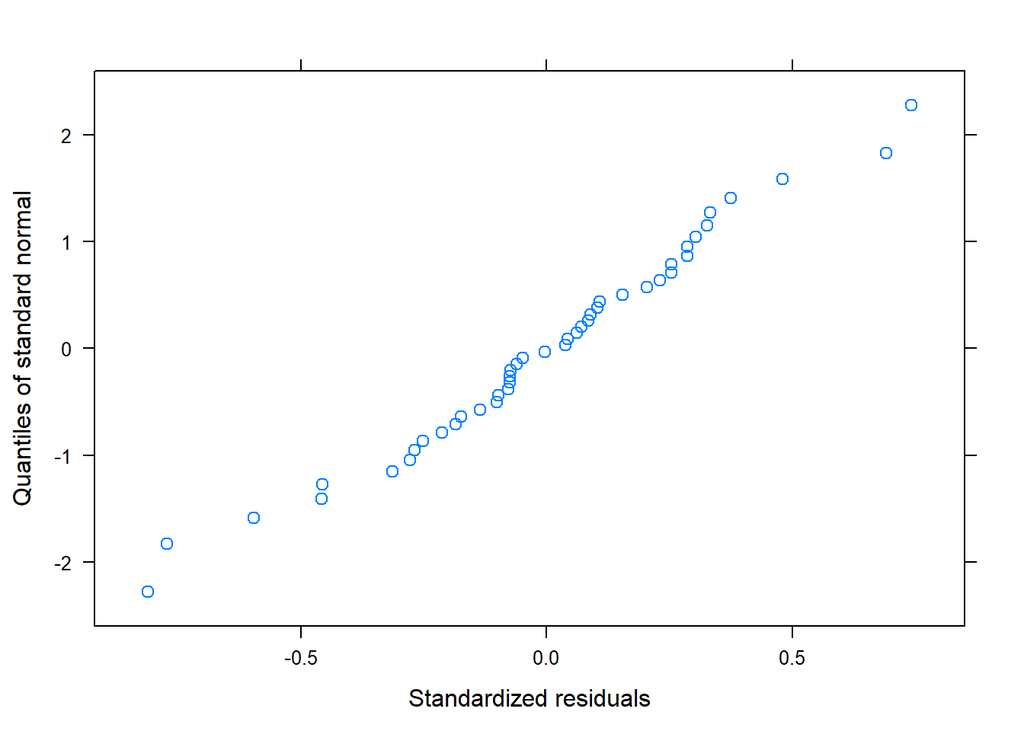

```r
qqnorm(lme.ile.pd1)
```

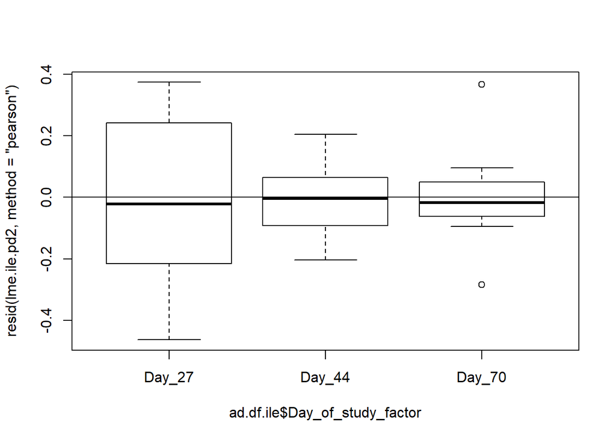

```r
plot(resid(lme.ile.pd2, method= "pearson")~ad.df.ile$Day_of_study_factor); abline(0,0)
```

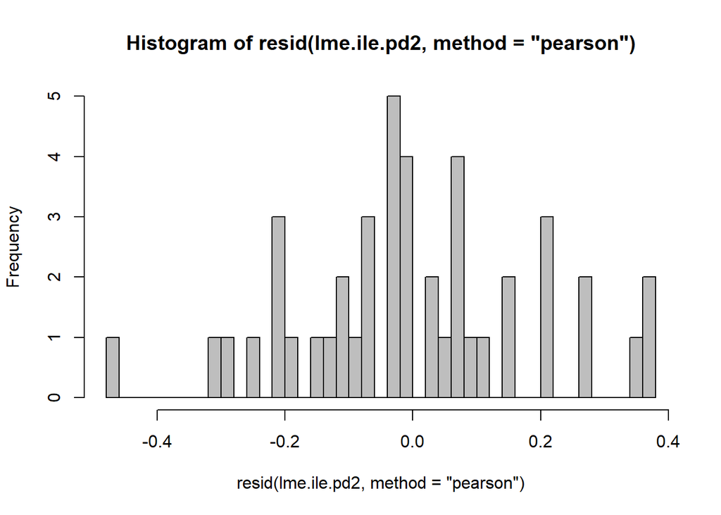

```r
hist(resid(lme.ile.pd2, method= "pearson"), breaks=30, col="grey")
```

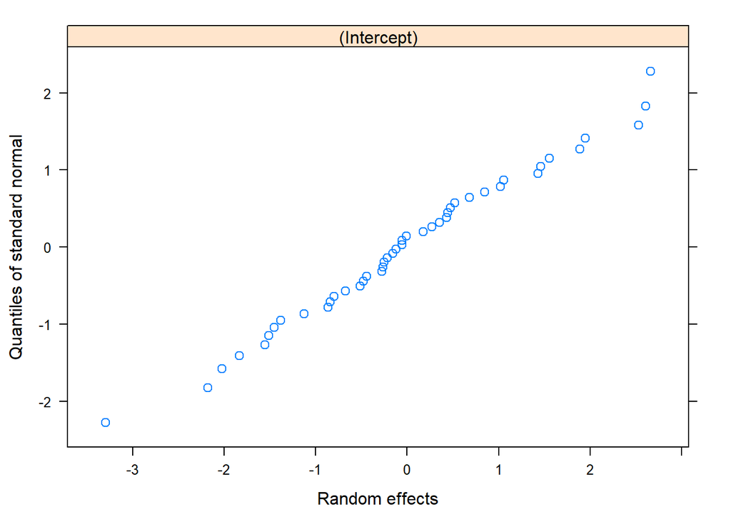

```r
qqnorm(lme.ile.pd2, ∼ranef (.))
```

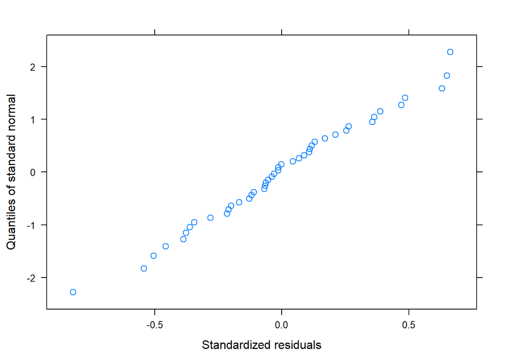

```r
qqnorm(lme.ile.pd2)
```

```r
# model output
aov.pd.ls1 <- anova(lme.ile.pd1)
aov.pd.ls1
```

```
##                               numDF denDF   F-value p-value
## (Intercept)                       1    38 1237.8926  <.0001
## Day_of_study_factor               2    38   30.7933  <.0001
## Treatment                         1    38    0.9861  0.3270
## Day_of_study_factor:Treatment     2    38    0.7677  0.4711
```

```r
aov.pd.ls2 <- anova(lme.ile.pd2)
aov.pd.ls2
```

```
##                               numDF denDF  F-value p-value
## (Intercept)                       1    38 451.2633  <.0001
## Day_of_study_factor               2    38  52.7914  <.0001
## Treatment                         1    38   3.8176  0.0581
## Day_of_study_factor:Treatment     2    38   2.3983  0.1045
```

```r
# test differences between timepoints - Shannon diversity
res.aov2 <- aov(Shannon ~ Day_of_study_factor, data = ad.df.ile)
summary(res.aov2)
```

```
##                     Df Sum Sq Mean Sq F value   Pr(>F)
## Day_of_study_factor  2  9.092   4.546   31.16 5.91e-09 ***
## Residuals           41  5.982   0.146
## ---
## Signif. codes:  0 '***' 0.001 '**' 0.01 '*' 0.05 '.' 0.1 ' ' 1
```

```r
TukeyHSD(res.aov2, which = "Day_of_study_factor")
```

```
##   Tukey multiple comparisons of means
##     95% family-wise confidence level
##
## Fit: aov(formula = Shannon ~ Day_of_study_factor, data = ad.df.ile)
##
## $Day_of_study_factor
##                     diff        lwr        upr     p adj
## Day_44-Day_27 -1.0211376 -1.3549503 -0.6873249 0.0000000
## Day_70-Day_27 -0.8605586 -1.2125154 -0.5086018 0.0000015
## Day_70-Day_44  0.1605790 -0.1862337  0.5073917 0.5038774
```

```r
# test differences between timepoints - InvSimpson diversity
res.aov2 <- aov(InvSimpson ~ Day_of_study_factor, data = ad.df.ile)
summary(res.aov2)
```

```
##                     Df Sum Sq Mean Sq F value   Pr(>F)
## Day_of_study_factor  2  272.1  136.07   46.43 2.92e-11 ***
## Residuals           41  120.2    2.93
## ---
## Signif. codes:  0 '***' 0.001 '**' 0.01 '*' 0.05 '.' 0.1 ' ' 1
```

```r
TukeyHSD(res.aov2, which = "Day_of_study_factor")
```

```
##   Tukey multiple comparisons of means
##     95% family-wise confidence level
##
## Fit: aov(formula = InvSimpson ~ Day_of_study_factor, data = ad.df.ile)
##
## $Day_of_study_factor
##                    diff       lwr       upr   p adj
## Day_44-Day_27 -5.376613 -6.872672 -3.880554 0.00000
## Day_70-Day_27 -5.072451 -6.649827 -3.495075 0.00000
## Day_70-Day_44  0.304162 -1.250160  1.858484 0.88303
```

## 4.12. Alpha diversity - caecum digesta

```r
# calculate Shannon and InvSimpson alpha diversity and add metadata
ad.df.cae <- data.frame("Description" = colnames(ps1.cae.otu))

ad.df.cae$Shannon <- estimate_richness(ps1.cae)$Shannon
ad.df.cae$InvSimpson <- estimate_richness(ps1.cae)$InvSimpson
ad.df.cae <- merge(meta(ps1.cae.r), ad.df.cae, by = "Description", all.x=T)

ad.df.cae <- ad.df.cae
```

## 4.13. LME caecum luminal samples

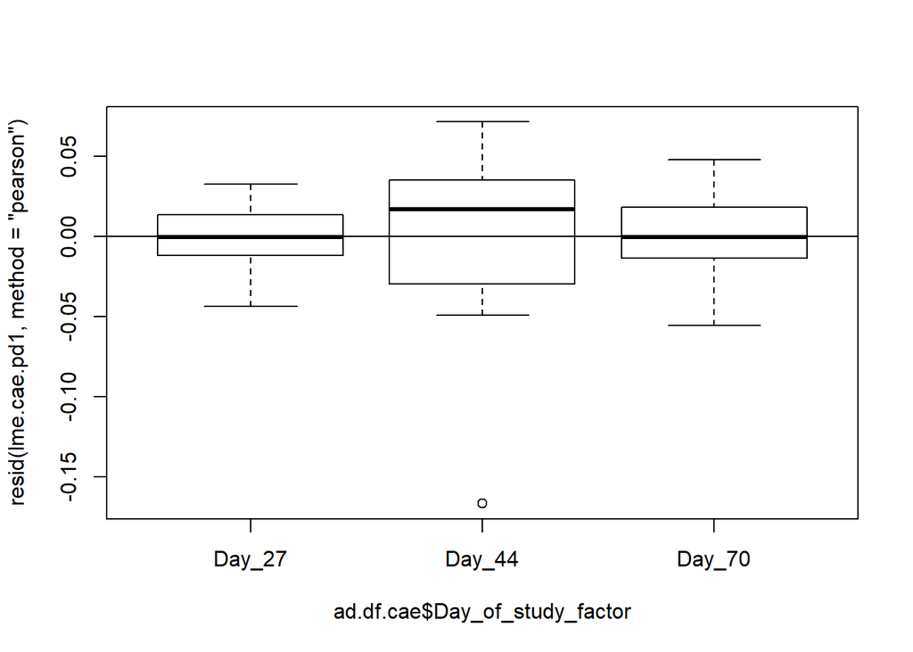

```r
# mixed model: random term and variance structure
lme.cae.pd1 <- lme(Shannon ~ Day_of_study_factor * Treatment,
              data = ad.df.cae, method = "REML",
              random = ~ 1 | Ear_tag)

lme.cae.pd2 <- lme(InvSimpson ~ Day_of_study_factor * Treatment,
              data = ad.df.cae, method = "REML",
              random = ~ 1 | Ear_tag)


# residual plots to visually inspect normality assumption
plot(resid(lme.cae.pd1, method= "pearson")~ad.df.cae$Day_of_study_factor); abline(0,0)
```

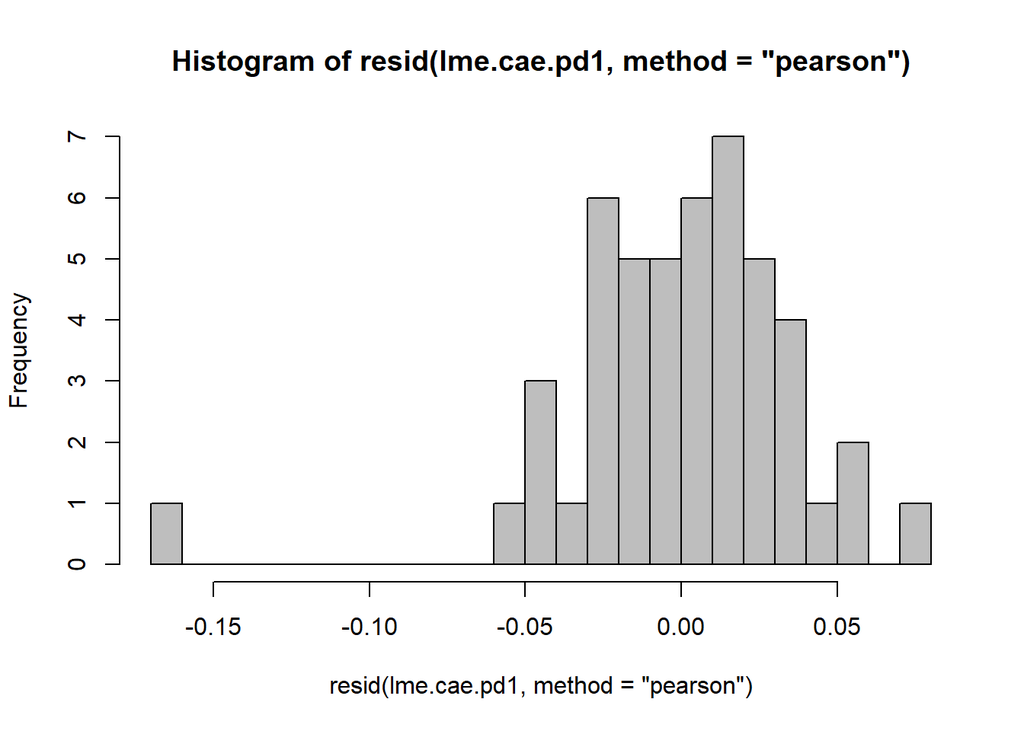

```r
hist(resid(lme.cae.pd1, method= "pearson"), breaks=30, col="grey")
```

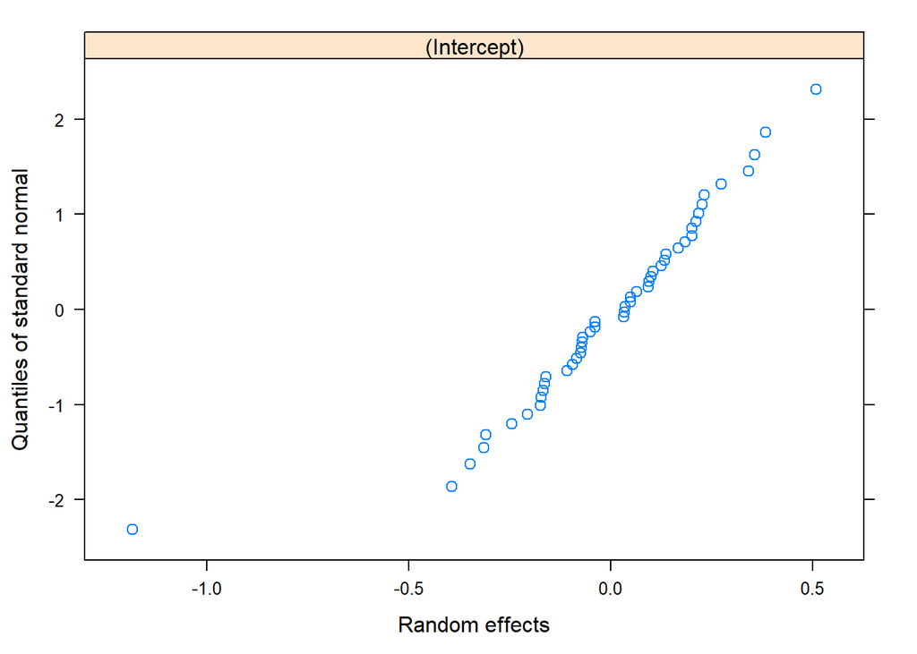

```r
qqnorm(lme.cae.pd1, ∼ranef (.))
```

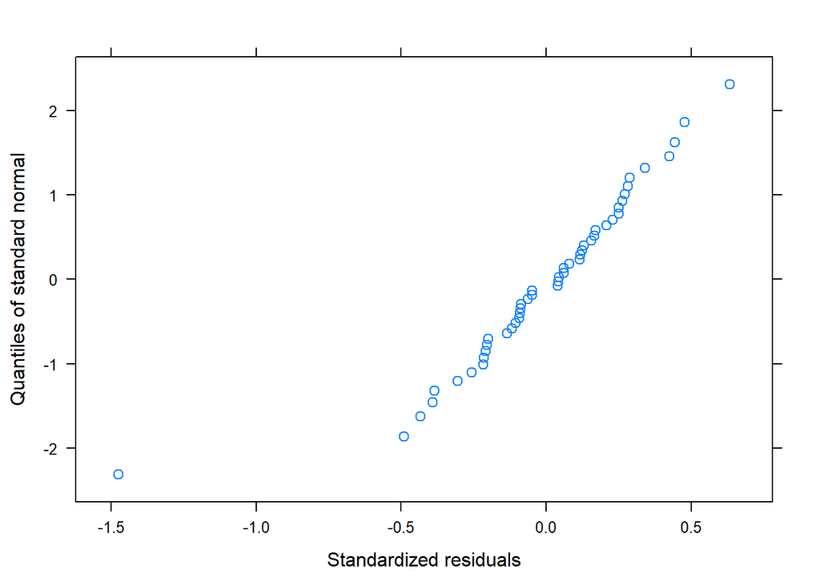

```r
qqnorm(lme.cae.pd1)
```

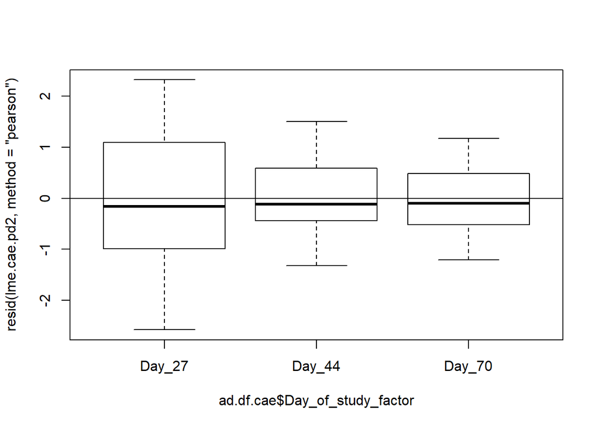

```r
plot(resid(lme.cae.pd2, method= "pearson")~ad.df.cae$Day_of_study_factor); abline(0,0)
```

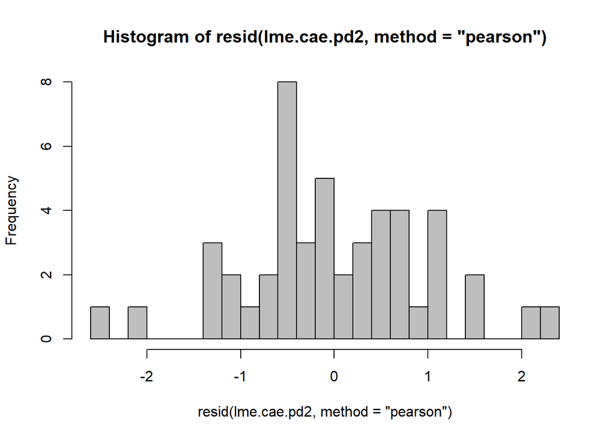

```r
hist(resid(lme.cae.pd2, method= "pearson"), breaks=30, col="grey")
```

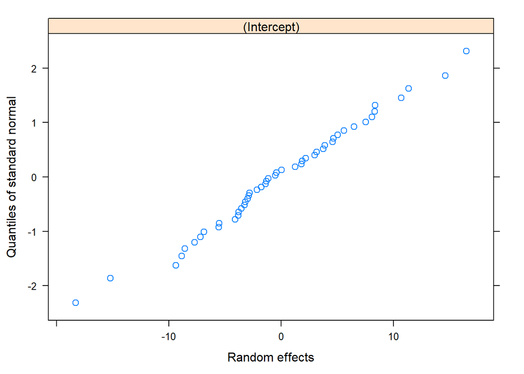

```r
qqnorm(lme.cae.pd2, ∼ranef (.))
```

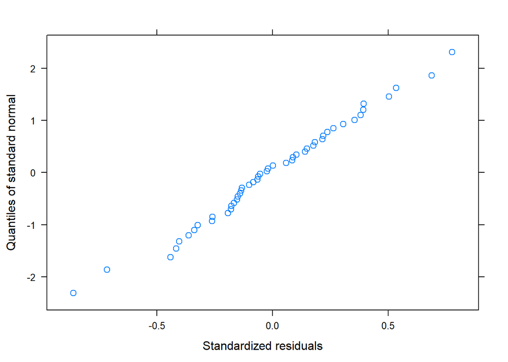

```r
qqnorm(lme.cae.pd2)
```

```r
# model output
aov.pd.ls1 <- anova(lme.cae.pd1)
aov.pd.ls1
```

```
##                               numDF denDF  F-value p-value
## (Intercept)                       1    42 6765.088  <.0001
## Day_of_study_factor               2    42   19.930  <.0001
## Treatment                         1    42    0.091  0.7648
## Day_of_study_factor:Treatment     2    42    1.534  0.2275
```

```r
aov.pd.ls2 <- anova(lme.cae.pd2)
aov.pd.ls2
```

```
##                               numDF denDF  F-value p-value
## (Intercept)                       1    42 412.5819  <.0001
## Day_of_study_factor               2    42  21.9302  <.0001
## Treatment                         1    42   0.1404  0.7098
## Day_of_study_factor:Treatment     2    42   0.8890  0.4187
```

```r
# test differences between timepoints - Shannon diversity
res.aov2 <- aov(Shannon ~ Day_of_study_factor, data = ad.df.cae)
summary(res.aov2)
```

```
##                     Df Sum Sq Mean Sq F value   Pr(>F)
## Day_of_study_factor  2  4.122  2.0611   19.86 6.57e-07 ***
## Residuals           45  4.670  0.1038
## ---
## Signif. codes:  0 '***' 0.001 '**' 0.01 '*' 0.05 '.' 0.1 ' ' 1
```

```r
TukeyHSD(res.aov2, which = "Day_of_study_factor")
```

```
##   Tukey multiple comparisons of means
##     95% family-wise confidence level
##
## Fit: aov(formula = Shannon ~ Day_of_study_factor, data = ad.df.cae)
##
## $Day_of_study_factor
##                     diff         lwr         upr     p adj
## Day_44-Day_27 -0.7176074 -0.99364948 -0.44156527 0.0000003
## Day_70-Day_27 -0.3741400 -0.65018207 -0.09809786 0.0055161
## Day_70-Day_44  0.3434674  0.06742531  0.61950952 0.0114964
```

```r
# test differences between timepoints - InvSimpson diversity
res.aov2 <- aov(InvSimpson ~ Day_of_study_factor, data = ad.df.cae)
summary(res.aov2)
```

```
##                     Df Sum Sq Mean Sq F value   Pr(>F)
## Day_of_study_factor  2   3175  1587.4   22.47 1.71e-07 ***
## Residuals           45   3179    70.6
## ---
## Signif. codes:  0 '***' 0.001 '**' 0.01 '*' 0.05 '.' 0.1 ' ' 1
```

```r
TukeyHSD(res.aov2, which = "Day_of_study_factor")
```

```
##   Tukey multiple comparisons of means
##     95% family-wise confidence level
##
## Fit: aov(formula = InvSimpson ~ Day_of_study_factor, data = ad.df.cae)
##
## $Day_of_study_factor
##                     diff        lwr        upr     p adj
## Day_44-Day_27 -19.865000 -27.067086 -12.662915 0.0000001
## Day_70-Day_27 -11.226777 -18.428862  -4.024691 0.0013187
## Day_70-Day_44   8.638223   1.436138  15.840309 0.0152966
```

# 5. Community composition analyses

## 5.1. Load data

```r
ps1.glucan <- readRDS("./phyobjects/ps1.glucan.rds")
print(ps1.glucan)
```

```
## phyloseq-class experiment-level object
## otu_table()   OTU Table:         [ 2969 taxa and 421 samples ]
## sample_data() Sample Data:       [ 421 samples by 115 sample variables ]
## tax_table()   Taxonomy Table:    [ 2969 taxa by 6 taxonomic ranks ]
## phy_tree()    Phylogenetic Tree: [ 2969 tips and 2968 internal nodes ]
```

```r
ps1.glucan@sam_data$Day_of_study <- factor(ps1.glucan@sam_data$Day_of_study, levels = c("Day_4", "Day_8", "Day_14", "Day_26", "Day_27", "Day_35", "Day_43", "Day_44", "Day_59", "Day_69", "Day_70"))
ps1.glucan@sam_data$Pre_or_post_weaning <- factor(ps1.glucan@sam_data$Pre_or_post_weaning, levels = c("Pre-weaning", "Post-weaning"))
ps1.glucan@sam_data$Origin_Day <- factor(ps1.glucan@sam_data$Origin_Day, levels = c("faeces_Day_4", "faeces_Day_8", "faeces_Day_14", "faeces_Day_26", "faeces_Day_35", "faeces_Day_43", "faeces_Day_59", "faeces_Day_69", "jejunum_digesta_Day_27", "jejunum_digesta_Day_44", "jejunum_digesta_Day_70", "ileum_digesta_Day_27", "ileum_digesta_Day_44", "ileum_digesta_Day_70", "caecum_digesta_Day_27", "caecum_digesta_Day_44", "caecum_digesta_Day_70"))
```

## 5.2. Prepare data

```r
ps1.subset <- subset_samples(ps1.glucan, Origin %in% c("faeces", "jejunum_digesta", "ileum_digesta", "caecum_digesta"))
ps1.subset <- prune_taxa(taxa_sums(otu_table(ps1.subset))>0, ps1.subset)

taxic <- as.data.frame(ps1.subset@tax_table)
taxic$OTU <- rownames(taxic)
tax_table(ps1.subset) <- tax_table(as.matrix(taxic))
ps1.subset@phy_tree <- NULL

ps1.fam <- microbiome::aggregate_top_taxa(ps1.subset, "Family", top = 25)
ps1.fam.r <- microbiome::transform(ps1.fam, "compositional")
```

## 5.3. Plot presets

```r
getPalette = colorRampPalette(brewer.pal(12, "Paired"))

guide_italics <- guides(fill = guide_legend(label.theme = element_text(size = 15,
    face = "italic", colour = "Black", angle = 0)))
```

## 5.4. Barplots

Barplot family level

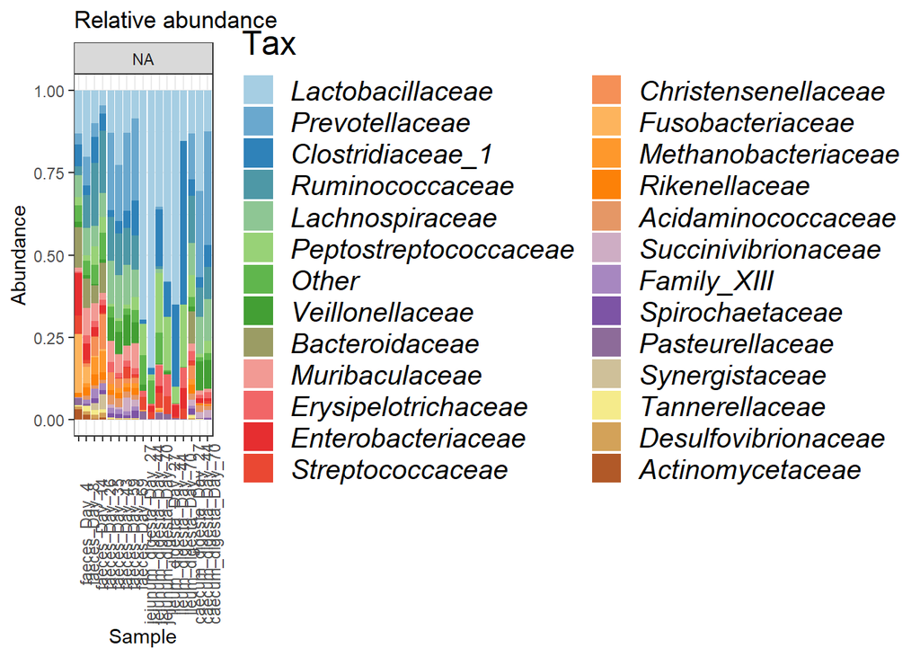

```r
pFam1 <- plot_composition(ps1.fam.r, x.label = "Treatment",
                          otu.sort = "abundance",
                          group_by = "Origin_Day", average_by = "Origin_Day") +
  scale_fill_manual(values = getPalette(26)) + theme_bw() +
  theme(axis.text.x = element_text(angle = 90),
        legend.title = element_text(size=18),
        legend.position = "right") +
  ggtitle("Relative abundance") + guide_italics
pFam1
```

```r
pdf(file = "./figures/Barplot_Family.pdf", height = 10, width = 15)
pFam1
dev.off() #The final figure can be found under panel B in Figure 3 of the manuscript
```

Barplot on Phylum level - prepare data

```r
ps1.subset <- subset_samples(ps1.glucan, Origin %in% c("faeces", "jejunum_digesta", "ileum_digesta", "caecum_digesta"))
ps1.subset <- prune_taxa(taxa_sums(otu_table(ps1.subset))>0, ps1.subset)

taxic <- as.data.frame(ps1.subset@tax_table)
taxic$OTU <- rownames(taxic)
tax_table(ps1.subset) <- tax_table(as.matrix(taxic))
ps1.subset@phy_tree <- NULL

ps1.phyl <- microbiome::aggregate_top_taxa(ps1.subset, "Phylum", top = 10)
ps1.phyl.r <- microbiome::transform(ps1.phyl, "compositional")
```

Barplot Phylum level

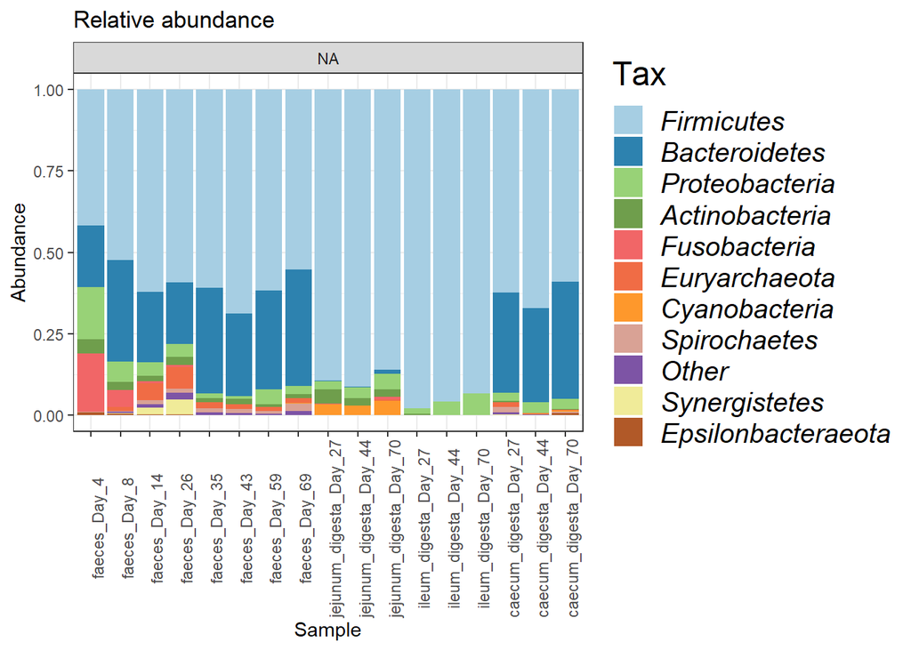

```r
pphyl1 <- plot_composition(ps1.phyl.r, sample.sort = "neatmap", x.label = "Treatment", otu.sort = "abundance", group_by = "Origin_Day", average_by = "Origin_Day") +
  scale_fill_manual(values = getPalette(11)) + theme_bw() +
  theme(axis.text.x = element_text(angle = 90),
        legend.title = element_text(size=18),
        legend.position = "right") +
  ggtitle("Relative abundance") + guide_italics
pphyl1
```

```r
pdf(file = "./figures/Barplot_Phylum.pdf", height = 10, width = 12)
pphyl1
dev.off() #The final figure can be found under panel A in Figure 3 of the manuscript
```

Barplot with Archaea - prepare data

```r
ps1.glucan.r <- microbiome::transform(ps1.glucan, "compositional")

ps1.archaea <- subset_taxa(ps1.glucan.r, Phylum == "Euryarchaeota")
ps1.archaea
```

```
## phyloseq-class experiment-level object
## otu_table()   OTU Table:         [ 22 taxa and 421 samples ]
## sample_data() Sample Data:       [ 421 samples by 115 sample variables ]
## tax_table()   Taxonomy Table:    [ 22 taxa by 6 taxonomic ranks ]
## phy_tree()    Phylogenetic Tree: [ 22 tips and 21 internal nodes ]
```

```r
ps1.subset <- subset_samples(ps1.archaea, Origin %in% c("faeces", "jejunum_digesta", "ileum_digesta", "caecum_digesta"))
ps1.subset <- prune_taxa(taxa_sums(otu_table(ps1.subset))>0, ps1.subset)

taxic <- as.data.frame(ps1.subset@tax_table)
taxic$OTU <- rownames(taxic)
tax_table(ps1.subset) <- tax_table(as.matrix(taxic))
ps1.subset@phy_tree <- NULL

ps1.phyl <- microbiome::aggregate_top_taxa(ps1.subset, "Genus", top = 10)
```

Barplot with Archaea

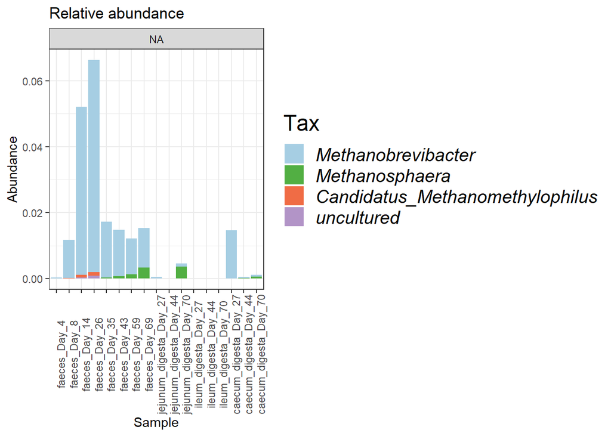

```r
pphyl1 <- plot_composition(ps1.phyl, x.label = "Treatment", otu.sort = "abundance", group_by = "Origin_Day", average_by = "Origin_Day") +
  scale_fill_manual(values = getPalette(5)) + theme_bw() +
  theme(axis.text.x = element_text(angle = 90),
        legend.title = element_text(size=18),
        legend.position = "right") +
  ggtitle("Relative abundance") + guide_italics
pphyl1
```

```r
pdf(file = "./figures/Barplot_Genus_archaea.pdf", height = 10, width = 13)
pphyl1
dev.off() #The final figure can be found as Supplementary Figure S5 of the manuscript
```

```r
data <- pphyl1$data #data object generated to investigate abundances of Archaea
```

# 6. Beta-diversity analysis

## 6.1. Input data PCoA plot

Input data Principal Coordinates Analysis plot

```r
ps1 <- readRDS("./phyobjects/ps1.glucan.rds")

ps1@sam_data$Day_of_study_factor <- factor(ps1@sam_data$Day_of_study_factor, levels = c("Day_4", "Day_8", "Day_14", "Day_26", "Day_27", "Day_35", "Day_43", "Day_44", "Day_59", "Day_69", "Day_70"))
ps1@sam_data$Pre_or_post_weaning <- factor(ps1@sam_data$Pre_or_post_weaning, levels = c("Pre_weaning", "Post_weaning"))

ps1 <- subset_samples(ps1, Origin %in% c("faeces"))
ps1 <- prune_taxa(taxa_sums(ps1) > 0, ps1)
ps1 <- microbiome::transform(ps1, "compositional")
```

## 6.2. Principal Coordinates Analysis plot

Ordination plot based on Weighted Unifrac

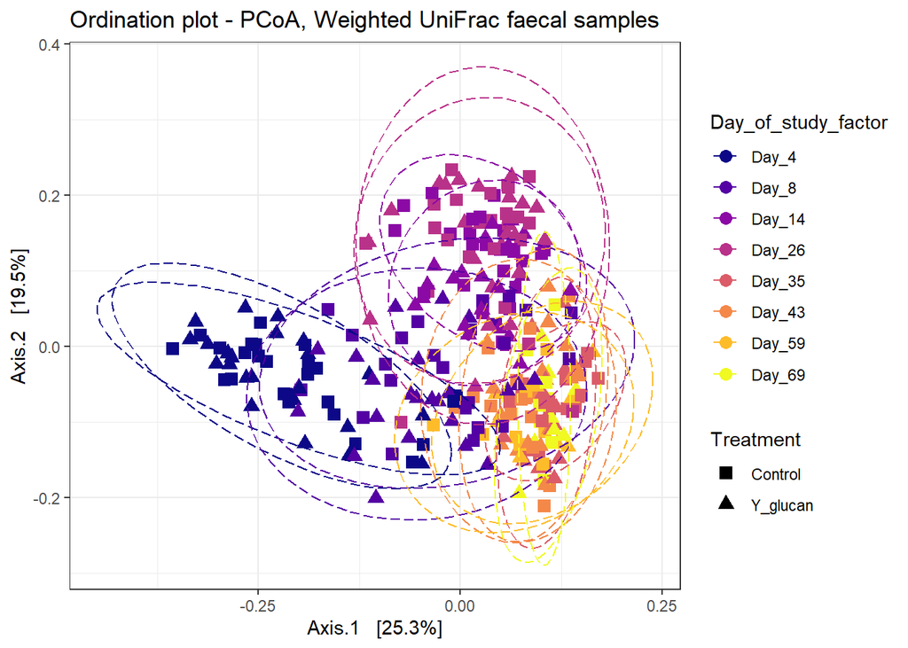

```r
set.seed(49275)
ordu.wt.uni = ordinate(ps1, "PCoA", "unifrac", weighted=TRUE)

wt.unifrac <- plot_ordination(ps1, ordu.wt.uni, color="Day_of_study_factor", shape="Treatment")
wt.unifrac <- wt.unifrac + scale_color_viridis(discrete = TRUE, option = "C")+ scale_fill_viridis(discrete = TRUE) +
ggtitle("Ordination plot - PCoA, Weighted UniFrac faecal samples") + geom_point(size = 3) + scale_shape_manual(values=c(15,17))
wt.unifrac <- wt.unifrac +
  stat_ellipse(type = "norm", linetype = 5) +
  theme_bw()
print(wt.unifrac)
```

```r
pdf(file = "./figures/PCoA_wt.unifrac.pdf", height = 10, width = 15)
wt.unifrac
dev.off() #The final figure can be found as Figure 4 of the manuscript
```

## 6.3. Load beta-diversity data

```r
ps1 <- readRDS("./phyobjects/ps1.glucan.rds")

ps1@sam_data$Day_of_study_factor <- factor(ps1@sam_data$Day_of_study_factor, levels = c("Day_4", "Day_8", "Day_14", "Day_26", "Day_27", "Day_35", "Day_43", "Day_44", "Day_59", "Day_69", "Day_70"))
ps1@sam_data$Pre_or_post_weaning <- factor(ps1@sam_data$Pre_or_post_weaning, levels = c("Pre_weaning", "Post_weaning"))

# subsetting
ps1.fcs <- subset_samples(ps1, Origin %in% c("faeces"))
ps1.fcs.pre <- subset_samples(ps1.fcs, Pre_or_post_weaning %in% c("Pre_weaning"))

ps1.fcs.r <- microbiome::transform(ps1.fcs, "compositional")
ps1.fcs.pre.r <- microbiome::transform(ps1.fcs.pre, "compositional")

# Conversions of data for Adonis tests
fcs.otu <- abundances(ps1.fcs.r)
fcs.meta <- meta(ps1.fcs.r)

fcs.otu.pre <- abundances(ps1.fcs.pre.r)
fcs.meta.pre <- meta(ps1.fcs.pre.r)
```

## 6.4. Visualize microbiome variation

Visualize the population density and highlight sample groups:

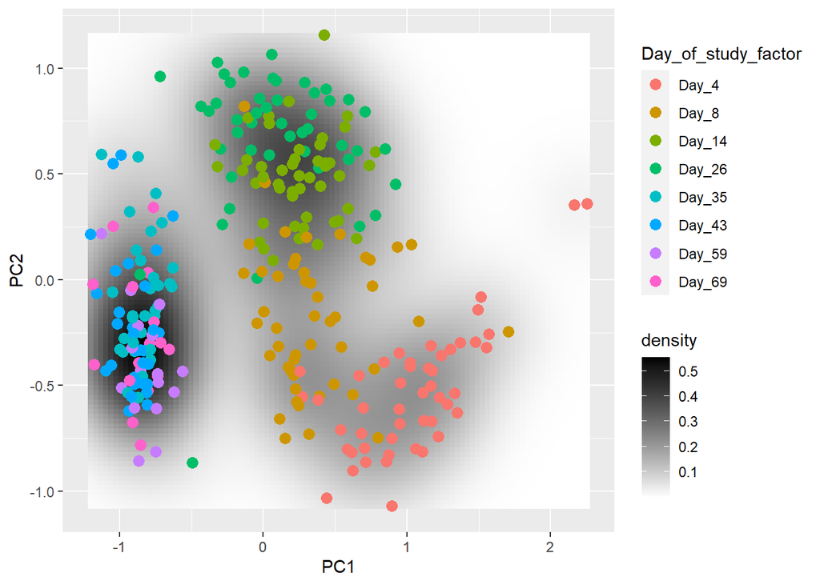

```r
p <- plot_landscape(ps1.fcs.r, method = "NMDS", distance = "bray", col = "Day_of_study_factor", size =3)
print(p)
```

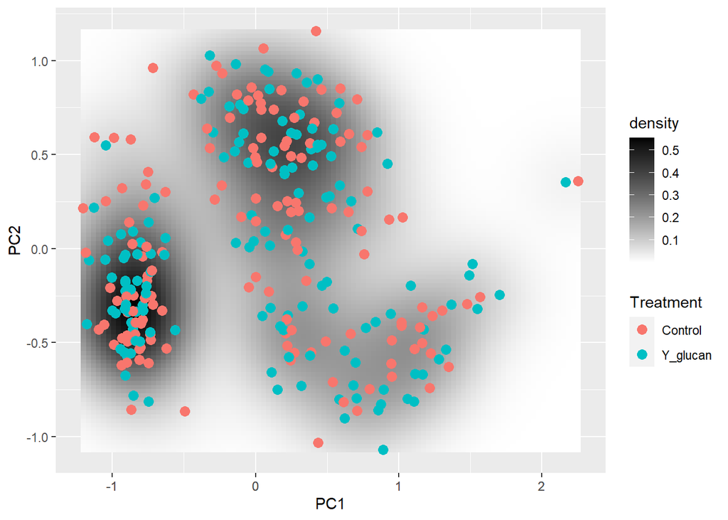

```r
p <- plot_landscape(ps1.fcs.r, method = "NMDS", distance = "bray", col = "Treatment", size =3)
print(p)
```

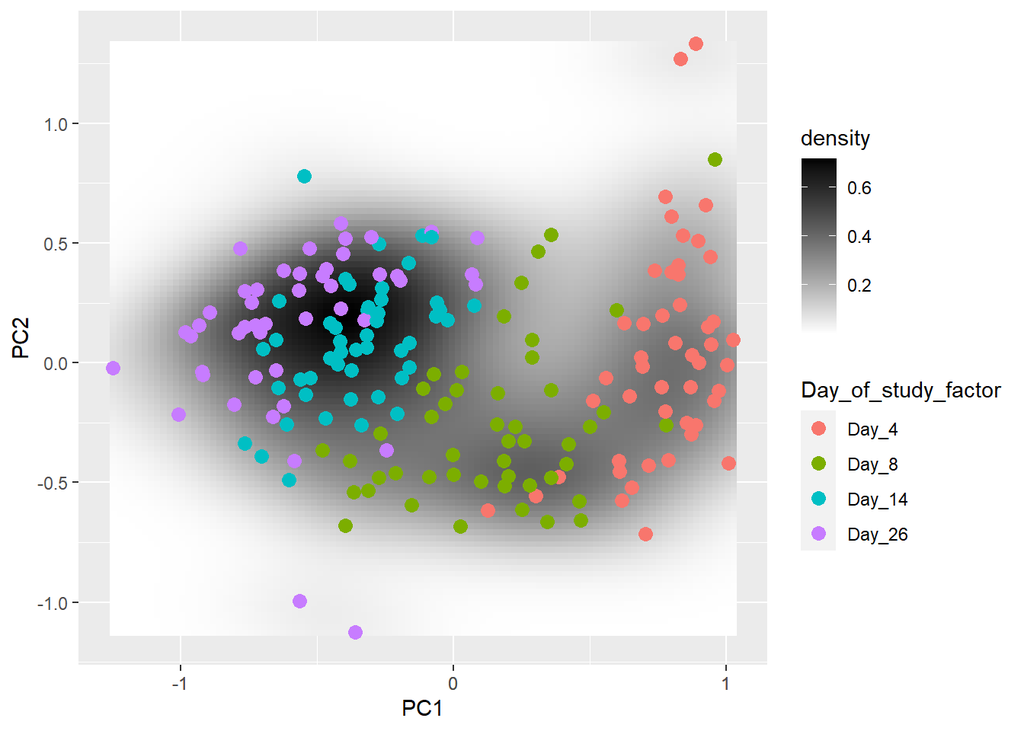

```r
p <- plot_landscape(ps1.fcs.pre.r, method = "NMDS", distance = "bray", col = "Day_of_study_factor", size =3)
print(p)
```

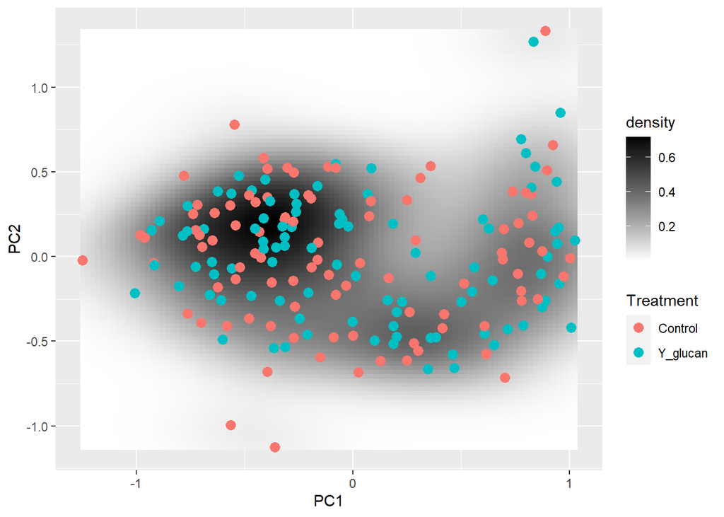

```r
p <- plot_landscape(ps1.fcs.pre.r, method = "NMDS", distance = "bray", col = "Treatment", size =3)
print(p)
```

## 6.5. PERMANOVA significance test

PERMANOVA significance test for group-level differences

```r
set.seed(343)
permanova <- adonis(t(fcs.otu) ~ Treatment + Day_of_study_factor,
                    data = fcs.meta, permutations=9999, method = "bray")

print(as.data.frame(permanova$aov.tab)) #no differences in beta-diversity between treatment groups
```

```
##                      Df   SumsOfSqs   MeanSqs   F.Model          R2 Pr(>F)
## Treatment             1   0.3128949 0.3128949  1.329623 0.003094676 0.1493
## Day_of_study_factor   7  35.3739595 5.0534228 21.474141 0.349864949 0.0001
## Residuals           278  65.4206145 0.2353260        NA 0.647040375     NA
## Total               286 101.1074689        NA        NA 1.000000000     NA
```

```r
set.seed(456)
permanova.pre <- adonis(t(fcs.otu.pre) ~ Treatment + Day_of_study_factor,
                    data = fcs.meta.pre, permutations=9999, method = "bray")

print(as.data.frame(permanova.pre$aov.tab)) #differences in beta-diversity between treatment groups
```

```
##                      Df  SumsOfSqs   MeanSqs   F.Model          R2 Pr(>F)
## Treatment             1  0.4374209 0.4374209  1.711205 0.006996515 0.0411
## Day_of_study_factor   3 14.5368011 4.8456004 18.956153 0.232515071 0.0001
## Residuals           186 47.5456012 0.2556215        NA 0.760488414     NA
## Total               190 62.5198232        NA        NA 1.000000000     NA
```

## 6.6. Checking homogeneity assumption

```r
# all faecal samples - dispersion between treatment groups
dist <- vegdist(t(fcs.otu), method="bray")

anova(betadisper(dist, fcs.meta$Treatment)) #no statistical significant differences in dispersion between treatment groups
```

```
## Analysis of Variance Table
##
## Response: Distances
##            Df  Sum Sq    Mean Sq F value Pr(>F)
## Groups      1 0.00054 0.00054152  0.2655 0.6068
## Residuals 285 0.58138 0.00203994
```

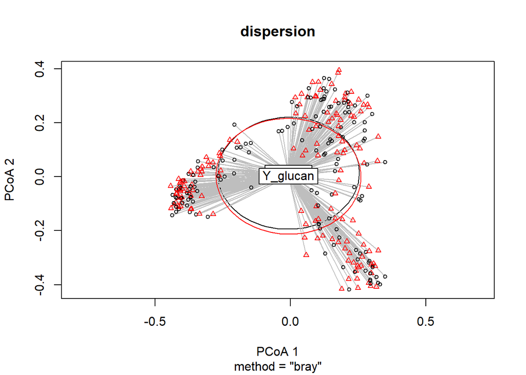

```r
dispersion <- betadisper(dist, group= fcs.meta$Treatment)

plot(dispersion, hull=FALSE, ellipse = TRUE)
```

```r
# dispersion pre- vs post-weaning
anova(betadisper(dist, fcs.meta$Pre_or_post_weaning)) #statistical significant differences in dispersion between pre- and post-weaning samples
```

```
## Analysis of Variance Table
##
## Response: Distances
##            Df  Sum Sq Mean Sq F value    Pr(>F)
## Groups      1 0.81987 0.81987  199.01 < 2.2e-16 ***
## Residuals 285 1.17414 0.00412
## ---
## Signif. codes:  0 '***' 0.001 '**' 0.01 '*' 0.05 '.' 0.1 ' ' 1
```

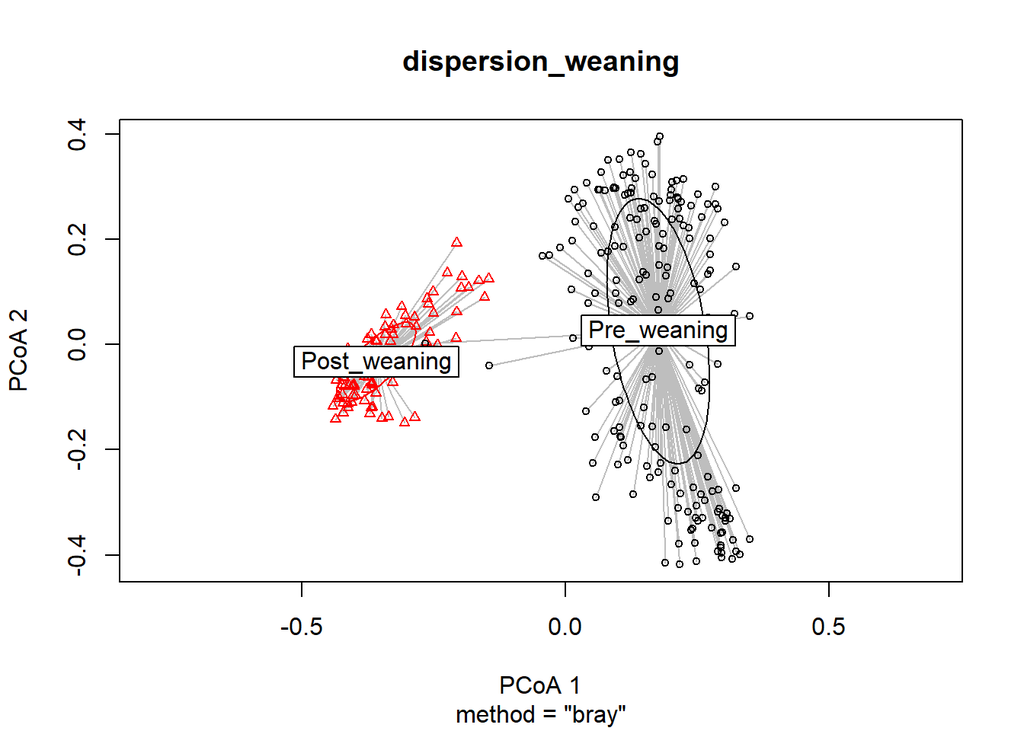

```r
dispersion_weaning <- betadisper(dist, group= fcs.meta$Pre_or_post_weaning)

plot(dispersion_weaning, hull=FALSE, ellipse = TRUE)
```

```r
# dispersion in each time-point
anova(betadisper(dist, fcs.meta$Day_of_study_factor)) #statistical significant differences in dispersion between time points
```

```
## Analysis of Variance Table
##
## Response: Distances
##            Df  Sum Sq  Mean Sq F value    Pr(>F)
## Groups      7 0.42241 0.060344  9.8852 5.101e-11 ***
## Residuals 279 1.70315 0.006104
## ---
## Signif. codes:  0 '***' 0.001 '**' 0.01 '*' 0.05 '.' 0.1 ' ' 1
```

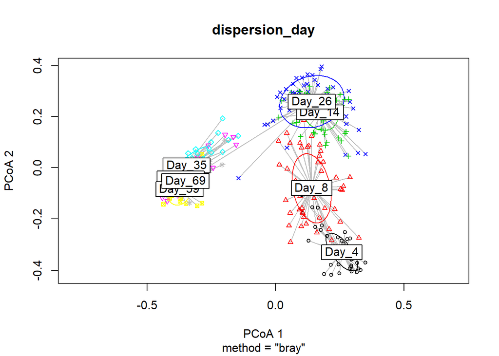

```r
dispersion_day <- betadisper(dist, group = fcs.meta$Day_of_study_factor)

plot(dispersion_day, hull=FALSE, ellipse = TRUE)
```

```r
# pre-weaning faecal samples - dispersion between treatment groups
dist.pre <- vegdist(t(fcs.otu.pre), method="bray")

anova(betadisper(dist.pre, fcs.meta.pre$Treatment)) #no statistical significant differences in dispersion between groups in pre-weaning faecal samples
```

```
## Analysis of Variance Table
##
## Response: Distances
##            Df  Sum Sq    Mean Sq F value Pr(>F)
## Groups      1 0.00087 0.00086817  0.2949 0.5878
## Residuals 189 0.55648 0.00294433
```

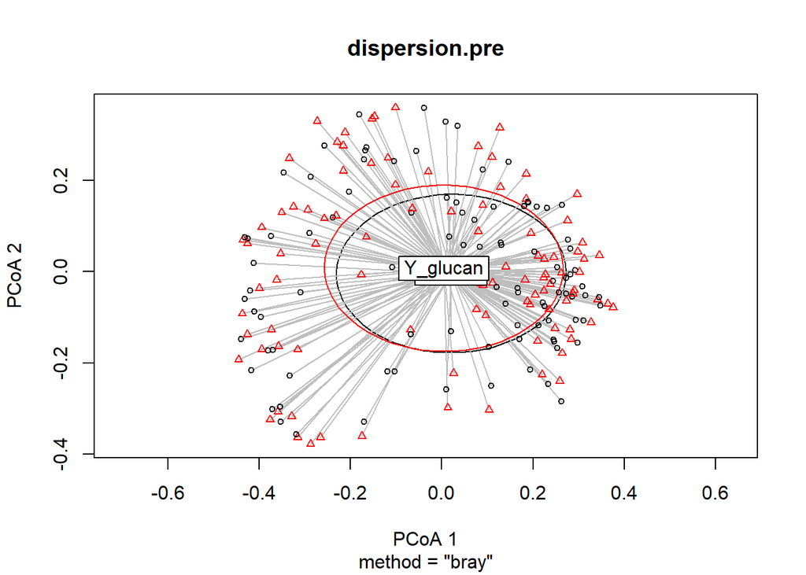

```r
dispersion.pre <- betadisper(dist.pre, group= fcs.meta.pre$Treatment)

plot(dispersion.pre, hull=FALSE, ellipse = TRUE)
```

```r
# pre-weaning faecal samples - dispersion in each time-point
anova(betadisper(dist.pre, fcs.meta.pre$Day_of_study_factor)) #no statistical significant differences in dispersion between timepoints in pre-weaning faecal samples
```

```
## Analysis of Variance Table
##
## Response: Distances
##            Df  Sum Sq  Mean Sq F value Pr(>F)
## Groups      3 0.03017 0.010056  1.9034 0.1305
## Residuals 187 0.98792 0.005283
```

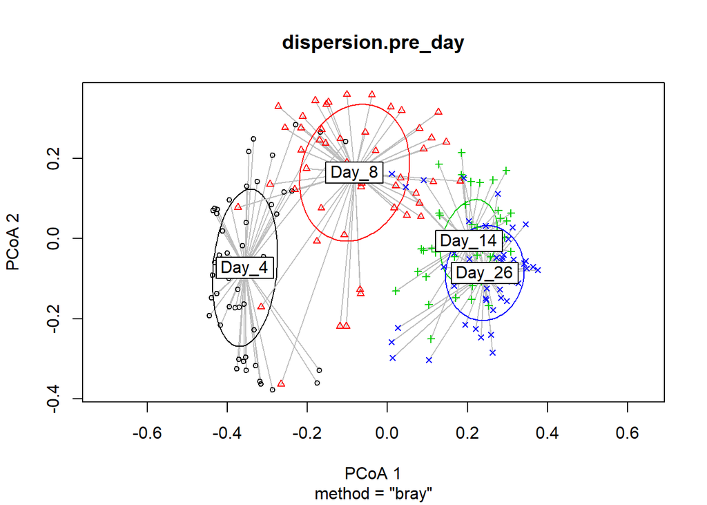

```r
dispersion.pre_day <- betadisper(dist.pre, group = fcs.meta.pre$Day_of_study_factor)

plot(dispersion.pre_day, hull=FALSE, ellipse = TRUE)
```

# 7. Abundance testing

## 7.1. Load data

```r
ps1.glucan <- readRDS("./phyobjects/ps1.glucan.rds")

ps1.glucan@sam_data$Day_of_study_factor <- factor(ps1.glucan@sam_data$Day_of_study_factor, levels = c("Day_4", "Day_8", "Day_14", "Day_26", "Day_27", "Day_35", "Day_43", "Day_44", "Day_59", "Day_69", "Day_70"))

ps1.glucan.g <- tax_glom(ps1.glucan, "Genus")
ps1.glucan.g.r <- microbiome::transform(ps1.glucan.g, "compositional")

ps1.glucan.g.r <- subset_samples(ps1.glucan.g.r, Origin %in% c("faeces"))
ps1.glucan.g.r <- subset_samples(ps1.glucan.g.r, Pre_or_post_weaning %in% c("Pre_weaning"))

ps1.glucan.g.r <- filter_taxa(ps1.glucan.g.r, function(x) sum(x > 0.001) > (0.50*length(x)), TRUE)
ps1.glucan.p <- prune_taxa(taxa_sums(otu_table(ps1.glucan.g.r)) > 0, ps1.glucan.g.r)

# tax table with OTU column and best_hit
glucan.tax <- as.data.frame(tax_table(ps1.glucan.g.r))
glucan.tax$OTU <- rownames(glucan.tax)
tax_table(ps1.glucan.g.r) <- tax_table(as.matrix(glucan.tax))
ps1.glucan.g.bh <- format_to_besthit(ps1.glucan.g.r)
glucan.tax.bh <- as.data.frame(tax_table(ps1.glucan.g.bh))
colnames(glucan.tax.bh)[7] <- "OTU"
```

## 7.2. Prepare data

```r
glucan.g.met <- meta(ps1.glucan.p)

glucan.g1 <- glucan.g.met[,c("Description","Ear_tag", "department_pre_weaning",
               "Treatment","Day_of_study_factor")]
# OTU table as dataframe:
glucan.g2 <- as.data.frame(t(otu_table(ps1.glucan.p)))
glucan.g2$Description <- rownames(glucan.g2)
# merge files
glucan.g3 <- merge(glucan.g1, glucan.g2, by = "Description")
colnames(glucan.g3)[6:36] <- paste("k__", sep = "", colnames(glucan.g3)[6:36])
```

## 7.3. Abundance testing

Abundance testing on pre-weaning faecal samples

```r
# Results, warnings and messages have been inactivated for this markdown, as otherwise it will use too much space in the HTML output file.
tc.treatment <- taxa.compare(taxtab = glucan.g3, propmed.rel = "gamlss",
                        transform = "none", comvar = "Treatment",
                        adjustvar = c("Day_of_study_factor", "department_pre_weaning"),
                        personid = "Ear_tag", longitudinal = "yes",
                        p.adjust.method = "fdr")

tc.glucan05 <- subset(tc.treatment, pval.adjust.TreatmentY_glucan < .05)

tc.glucan05$id <- droplevels(as.factor(tc.glucan05$id))

glucan3.m <- reshape2::melt(glucan.g3)
glucan3.max <- ddply(glucan3.m, .(variable), summarise, max = max(value))
glucan3.max1 <- glucan3.max
glucan3.max1$variable <- droplevels(glucan3.max1$variable)

# subset
glucan.g4 <- subset(glucan3.m, variable %in% tc.glucan05$id &
                variable %in% glucan3.max1$variable)

# create vector of genus names (OTU codes) to include in plots
select.gen.glucan <- levels(droplevels(glucan.g4$variable)) # 27 genera
select.gen.glucan <- sub("k__", "", select.gen.glucan) # remove "k__"
select.gen.glucan
```

## 7.4. Editing output

```r
tc.glucan.sub <- subset(tc.glucan05, id %in% glucan3.max1$variable)

# remove "k__" in id names
tc.glucan.sub$id <- as.factor(sub("k__", "", tc.glucan.sub$id))

# show tax names of output genera
glucan.g4.tax <- subset(glucan.tax.bh, OTU %in% select.gen.glucan) #significant genera

# create vectors of significant genera from comparisons
select.gen.glucan2 <- unique(c(as.character(select.gen.glucan)))
```

## 7.5. Prepare data for plotting

```r
# filter for genera from first output series of GAMLSS tests (select.gen.glucan2).

# object 1: metadata
glucan.tr.met <- meta(ps1.glucan.g.r)

glucan.tr1 <- glucan.tr.met[,c("Description","Ear_tag", "department_pre_weaning",
               "Treatment","Day_of_study_factor")]

# object 2: OTU table
glucan.tr2 <- as.data.frame(t(otu_table(ps1.glucan.g.r)))
glucan.tr2$Description <- rownames(glucan.tr2)
# melt glucan.tr2
glucan.tr2.m <- reshape2::melt(glucan.tr2)
colnames(glucan.tr2.m) <- c("Description", "OTU", "abund")
# merge glucan.tr2, glucan.tax and glucan.tr1
glucan.tr3a <- base::merge(glucan.tr2.m, glucan.tax, by = "OTU")
glucan.tr3 <- base::merge(glucan.tr1, glucan.tr3a, by = "Description")

# subset to signif genera and max(abund) > 0.1
glucan.tr3.max <- ddply(glucan.tr3, .(OTU), summarise, max = max(abund))
glucan.tr3.max <- subset(glucan.tr3.max, max > .1)
glucan.tr3.max$OTU <- droplevels(glucan.tr3.max$OTU)
glucan.tr3.s <- subset(glucan.tr3, OTU %in% select.gen.glucan2 & OTU %in%
                     glucan.tr3.max$OTU)
glucan.tr3.s$OTU <- droplevels(glucan.tr3.s$OTU)
```

## 7.6. Plot presets

```r
theme4 <- theme_classic() +
  theme(panel.grid.major = element_line(colour = "grey80"),
        panel.spacing = unit(.5,"lines"),
        panel.border = element_rect(color = "black", fill = NA, size = .5),
        strip.background = element_blank(),
        strip.placement = "outside",
        text = element_text(size=15),
        axis.text.x = element_text(hjust = .5, vjust = .5),
        plot.title = element_text(size = 12))
labs_abd <- as_labeller(c(
  "faeces" = "Faeces", "ileum_digesta" = "Ileum digesta", "jejunum_digesta" = " Jejunum digesta"))
```

## 7.7. Plotting loop

```r
# for-loop
sig.plot <- list()
for(i in 1:nlevels(glucan.tr3.s$OTU)){
  a = levels(glucan.tr3.s$OTU)[i]
  B = glucan.tr3.s[glucan.tr3.s$OTU == a,]
  p = ggplot(B, aes(x = Day_of_study_factor, y = abund, colour = Treatment, alpha = 0.95)) +
    geom_boxplot(outlier.size = 0) +
    geom_point(size = 2, position = position_jitterdodge()) +
    labs(x="time (d)", y="rel. abundance") +
    scale_y_continuous(limits = c(0,1), n.breaks = 6) +
    ggtitle(paste(B$Order,B$Family,B$Genus,B$OTU)) + theme4
  sig.plot[[i]] = p
}

# print plots
pdf("./figures/Differential_abundant_genera.pdf")
for (i in 1:nlevels(glucan.tr3.s$OTU)) {
    print(sig.plot[[i]])
}
dev.off() #Resulting figures can be found under Figure 5 of the manuscript
```

# 8. Distance-based PRC

## 8.1. Load data and subset

```r
# only faeces pre-weaning
fcs.pre <- readRDS("./phyobjects/ps1.faeces.rds")
fcs.pre <- subset_samples(fcs.pre, Pre_or_post_weaning == "Pre_weaning")
fcs.pre <- prune_taxa(taxa_sums(otu_table(fcs.pre)) > 0, fcs.pre)

# only faeces post-weaning
fcs.post <- readRDS("./phyobjects/ps1.faeces.rds")
fcs.post <- subset_samples(fcs.post, Pre_or_post_weaning == "Post_weaning")
fcs.post <- prune_taxa(taxa_sums(otu_table(fcs.post)) > 0, fcs.post)

print(fcs.pre)
```

```
## phyloseq-class experiment-level object
## otu_table()   OTU Table:         [ 1640 taxa and 191 samples ]
## sample_data() Sample Data:       [ 191 samples by 115 sample variables ]
## tax_table()   Taxonomy Table:    [ 1640 taxa by 6 taxonomic ranks ]
## phy_tree()    Phylogenetic Tree: [ 1640 tips and 1639 internal nodes ]
```

```r
print(fcs.post)
```

```
## phyloseq-class experiment-level object
## otu_table()   OTU Table:         [ 1159 taxa and 96 samples ]
## sample_data() Sample Data:       [ 96 samples by 115 sample variables ]
## tax_table()   Taxonomy Table:    [ 1159 taxa by 6 taxonomic ranks ]
## phy_tree()    Phylogenetic Tree: [ 1159 tips and 1158 internal nodes ]
```

```r
# transform to relative abundance
fcs.pre.r <- microbiome::transform(fcs.pre, "compositional")
fcs.post.r <- microbiome::transform(fcs.post, "compositional")
```

## 8.2. PRC genus level - pre-weaning

```r
rank_names(fcs.pre.r)
```

```
## [1] "Domain" "Phylum" "Class"  "Order"  "Family" "Genus"
```

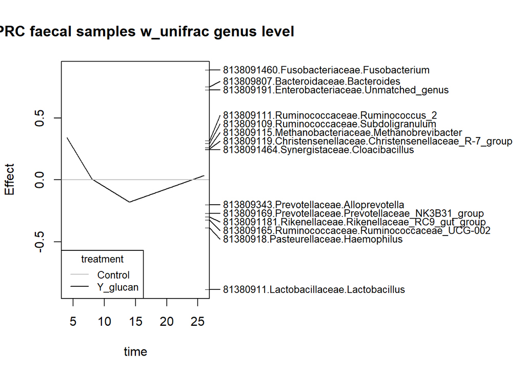

```r
pre.gen.r <- tax_glom(fcs.pre.r, taxrank = rank_names(fcs.pre.r) [6]) #Aggregate to genus level

# Add Family level names
taxa_names(pre.gen.r) <- interaction(rownames(pre.gen.r@tax_table[,c("Family")]),pre.gen.r@tax_table[,c("Family")])
# Add Genus level names
taxa_names(pre.gen.r) <- interaction(rownames(pre.gen.r@tax_table[,c("Genus")]),pre.gen.r@tax_table[,c("Genus")])

# Genus level
df.pre.gen.r <- as.data.frame(t(abundances(pre.gen.r)))
df.pre.gen.r$Description <- rownames(df.pre.gen.r)
dfm.pre.gen.r <- merge(meta(pre.gen.r)[c("Description","Treatment", "Day_of_study")], df.pre.gen.r, by="Description")

response<-dfm.pre.gen.r[,4:length(dfm.pre.gen.r)]
time<-as.factor(dfm.pre.gen.r[,3])
treatment<-as.factor(dfm.pre.gen.r[,2])

# Set up objects and matrices
y <- deparse(substitute(response))
x <- deparse(substitute(treatment))
z <- deparse(substitute(time))

# Create formulas and design matrices
fla <- as.formula(paste("~", x, "+", z))
mf <- model.frame(fla, response, na.action = na.pass)
fla.zx <- as.formula(paste("~", z, ":", x))
fla.z <- as.formula(paste("~", z))
X = model.matrix(fla.zx, mf)[, -c(seq_len(nlevels(time) + 1))]
Z = model.matrix(fla.z, mf)[, -1]

# Calculate Weighted UniFrac distance matrix
dm.pre.gen.r.wUF <- UniFrac(pre.gen.r, weighted = T)

# Calculation of UniFrac distance-based RDA
dbRDA.pre <- capscale(dm.pre.gen.r.wUF ~ X + Condition(Z), data = dfm.pre.gen.r[,2:3], comm = response)

# Conversion of dbRDA to PRC compatible format
dbRDA.pre$terminfo$xlev = list(levels(time), levels(treatment))
names(dbRDA.pre$terminfo$xlev) = c(paste(z), paste(x))
dbRDA.pre$call <- match.call()
class(dbRDA.pre) <- c("prc", class(dbRDA.pre))

sum_dbprc <- summary(dbRDA.pre)
plot(dbRDA.pre, main = "dbPRC faecal samples w_unifrac genus level", select = abs(sum_dbprc$sp) > 0.2)
```

```r
pdf(file = "./figures/prc_pre-weaning.pdf", height = 5, width = 8)
plot(dbRDA.pre, main = "dbPRC faecal samples w_unifrac genus level", select = abs(sum_dbprc$sp) > 0.2)
dev.off() #The final figure can be found under panel A in Supplementary Figure S4 of the manuscript
```

## 8.3. PRC genus level - post-weaning

```r
post.gen.r <- tax_glom(fcs.post.r, taxrank = rank_names(fcs.post.r) [6])

rank_names(post.gen.r)
```

```
## [1] "Domain" "Phylum" "Class"  "Order"  "Family" "Genus"
```

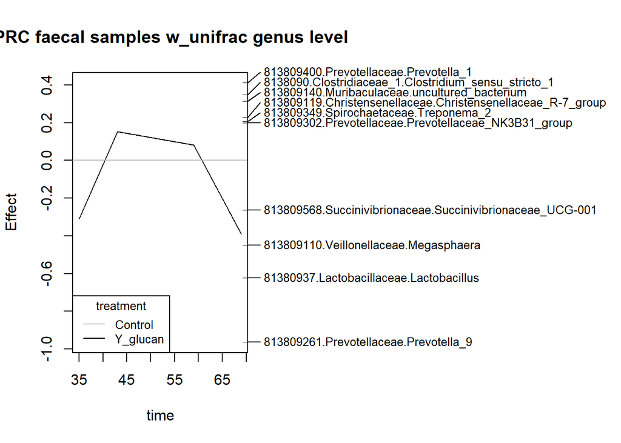

```r
# Add Family level names
taxa_names(post.gen.r) <- interaction(rownames(post.gen.r@tax_table[,c("Family")]),post.gen.r@tax_table[,c("Family")])
# Add Genus level names
taxa_names(post.gen.r) <- interaction(rownames(post.gen.r@tax_table[,c("Genus")]),post.gen.r@tax_table[,c("Genus")])

df.post.gen.r <- as.data.frame(t(abundances(post.gen.r)))
df.post.gen.r$Description <- rownames(df.post.gen.r)
dfm.post.gen.r <- merge(meta(post.gen.r)[c("Description","Treatment", "Day_of_study")], df.post.gen.r, by="Description")

response<-dfm.post.gen.r[,4:length(dfm.post.gen.r)]
time<-as.factor(dfm.post.gen.r[,3])
treatment<-as.factor(dfm.post.gen.r[,2])

# Set up objects and matrices
y <- deparse(substitute(response))
x <- deparse(substitute(treatment))
z <- deparse(substitute(time))

# Create formulas and design matrices
fla <- as.formula(paste("~", x, "+", z))
mf <- model.frame(fla, response, na.action = na.pass)
fla.zx <- as.formula(paste("~", z, ":", x))
fla.z <- as.formula(paste("~", z))
X = model.matrix(fla.zx, mf)[, -c(seq_len(nlevels(time) + 1))]
Z = model.matrix(fla.z, mf)[, -1]

# Calculate Weighted UniFrac distance matrix
dm.post.gen.r.wUF <- UniFrac(post.gen.r, weighted = T)

# Calculation of UniFrac distance based RDA
dbRDA.CFgen <- capscale(dm.post.gen.r.wUF ~ X + Condition(Z), data = dfm.post.gen.r[,2:3], comm = response)

# Conversion of dbRDA to PRC compatible format
dbRDA.CFgen$terminfo$xlev = list(levels(time), levels(treatment))
names(dbRDA.CFgen$terminfo$xlev) = c(paste(z), paste(x))
dbRDA.CFgen$call <- match.call()
class(dbRDA.CFgen) <- c("prc", class(dbRDA.CFgen))

sum_dbprc <- summary(dbRDA.CFgen)
plot(dbRDA.CFgen, main = "dbPRC faecal samples w_unifrac genus level", select = abs(sum_dbprc$sp) > 0.2)
```

```r
pdf(file = "./figures/prc_post-weaning.pdf", height = 5, width = 8)
plot(dbRDA.CFgen, main = "dbPRC faecal samples w_unifrac genus level", select = abs(sum_dbprc$sp) > 0.2)
dev.off() #The final figure can be found under panel B in Supplementary Figure S4 of the manuscript
```

# 9. Heatmap

## 9.1. Input data - top 35 families

```r
ps1 <- readRDS("./phyobjects/ps1.glucan.rds")

ps1@sam_data$Day_of_study_factor <- factor(ps1@sam_data$Day_of_study_factor, levels = c("Day_4", "Day_8", "Day_14", "Day_26", "Day_27", "Day_35", "Day_43", "Day_44", "Day_59", "Day_69", "Day_70"))
ps1@sam_data$Pre_or_post_weaning <- factor(ps1@sam_data$Pre_or_post_weaning, levels = c("Pre_weaning", "Post_weaning"))

ps1.fcs <- subset_samples(ps1, Origin %in% c("faeces"))
ps1.fcs.fam <- microbiome::aggregate_taxa(ps1.fcs, "Family")
# remove taxa with 0 abundance
ps1.fcs.fam <- prune_taxa(taxa_sums(otu_table(ps1.fcs.fam)) > 0, ps1.fcs.fam)
# add FAM column
ps1.fcs.fam.tax <- as.data.frame(ps1.fcs.fam@tax_table)
ps1.fcs.fam.tax$FAM <- rownames(ps1.fcs.fam.tax)
tax_table(ps1.fcs.fam) <- tax_table(as.matrix(ps1.fcs.fam.tax))
# relative abundance
ps1.fcs.fam.r <- microbiome::transform(ps1.fcs.fam, "compositional")

# select top 35 by summed rel. abund.
ps1.fcs.fam.abund <- abundances(ps1.fcs.fam.r)
ps1.fcs.fam.abund.m <- reshape2::melt(ps1.fcs.fam.abund)
colnames(ps1.fcs.fam.abund.m) <- c("FAM", "Description", "rel_abund")
ps1.fcs.fam.sum <- ddply(ps1.fcs.fam.abund.m, .(FAM), summarise, mean = mean(rel_abund))

ps1.fcs.fam.tax$reads <- taxa_sums(ps1.fcs.fam) # total reads per genus
ps1.fcs.fam.tax$sum_abund <- taxa_sums(ps1.fcs.fam.r) # summed relative abund.
ps1.fcs.fam.tax$mean_abund <- ps1.fcs.fam.sum$mean # mean relative abundance

# top 35
ps1.fcs.fam.top35 <- top_n(ps1.fcs.fam.tax, n = 35, wt = sum_abund)
ps1.fcs.fam.top35$FAM <- as.factor(ps1.fcs.fam.top35$FAM)

# top 35 with phy_tree
ps1.fcs.fam35.r <- subset_taxa(ps1.fcs.fam.r, FAM %in% ps1.fcs.fam.top35$FAM)
```

## 9.2. Plot presets

```r
theme_hm <- theme_classic() + theme(
  axis.text.y = element_text(colour = 'black', face = 'italic'),
  legend.key = element_blank(), text = element_text(size = 20),
  panel.spacing.x=unit(0, "lines"),
  strip.background = element_rect(colour="black", fill="white"))
```

## 9.3. Create heatmap plot data

```r
# create heatmap plot data
fam35.hm.df <- plot_heatmap(ps1.fcs.fam35.r, method = "CAP", distance = "bray",
                     formula = ~ Day_of_study_factor)$data

# clean up tax names
fam35.hm.df$taxname <- ifelse(fam35.hm.df$Family == "f__",
              yes = paste(fam35.hm.df$Class, "(unassigned)"),
              no = paste(fam35.hm.df$Family))
fam35.hm.df$taxname <- gsub(fam35.hm.df$taxname, pattern = "[a-z]__",
                          replacement = "")

# summarise per pen per timepoint
fam35.hm.sum <- ddply(fam35.hm.df, .(Day_of_study_factor, Origin, Pen_no_pre_weaning,
                               taxname, FAM),
                   summarise, median = median(Abundance),
                   mean = mean(Abundance))
fam35.hm.sum$group <- interaction(fam35.hm.sum$Origin,
                               fam35.hm.sum$Day_of_study_factor, fam35.hm.sum$Pen_no_pre_weaning,
                               drop=T)
fam35.hm.sum$taxname <- as.factor(fam35.hm.sum$taxname)

# Bray-curtis distance matrix for taxa clustering
fam35.hm.cast <- reshape2::dcast(fam35.hm.sum[,c(4,6,8)], taxname ~ group,
                              value.var = "median")
rownames(fam35.hm.cast) <- fam35.hm.cast[,1]
fam35.hm.mat <- as.matrix(fam35.hm.cast[,c(2:129)])
bray35.sp <- vegdist(fam35.hm.mat, method = "bray")

# reorder levels by clustering
sp.order <- hclust(bray35.sp)$order
fam35.hm.sum$taxname <- factor(fam35.hm.sum$taxname,
                            levels(fam35.hm.sum$taxname)[sp.order])
levels(fam35.hm.sum$taxname)
```

```
##  [1] "Akkermansiaceae"               "Corynebacteriaceae"
##  [3] "Desulfovibrionaceae"           "Tannerellaceae"
##  [5] "p-2534-18B5_gut_group"         "Pirellulaceae"
##  [7] "Synergistaceae"                "Clostridiales_vadinBB60_group"
##  [9] "Marinifilaceae"                "Atopobiaceae"
## [11] "Eggerthellaceae"               "Streptococcaceae"
## [13] "Succinivibrionaceae"           "Lactobacillaceae"
## [15] "Prevotellaceae"                "Lachnospiraceae"
## [17] "Ruminococcaceae"               "Muribaculaceae"
## [19] "Veillonellaceae"               "Christensenellaceae"
## [21] "Methanobacteriaceae"           "Clostridiaceae_1"
## [23] "Peptostreptococcaceae"         "Spirochaetaceae"
## [25] "Acidaminococcaceae"            "Erysipelotrichaceae"
## [27] "Family_XIII"                   "Rikenellaceae"
## [29] "Enterobacteriaceae"            "Bacteroidaceae"
## [31] "Fusobacteriaceae"              "Enterococcaceae"
## [33] "Campylobacteraceae"            "Actinomycetaceae"
## [35] "Pasteurellaceae"
```

## 9.4. Plot heatmap

With Bray-Curtis complete-linkage clustering of taxa.

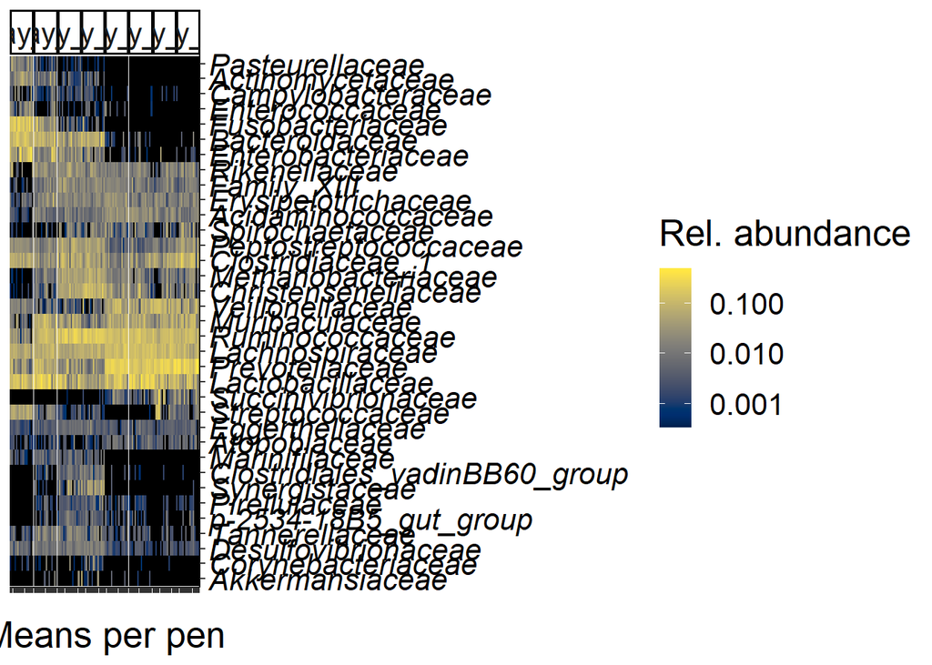

```r
theme_hm <- theme_classic() + theme(
  axis.text.y = element_text(colour = 'black', face = 'italic'),
  axis.text.x = element_text(size = 10, colour = 'white', face = 'italic'),
  legend.key = element_blank(), text = element_text(size = 20),
  panel.spacing.x=unit(0, "lines"),
  strip.background = element_rect(colour="black", fill="white"))

p.fam35.hm <- ggplot(fam35.hm.sum, aes(x=Pen_no_pre_weaning, y=taxname)) +
  geom_tile(aes(fill=mean)) +
  scale_fill_viridis("Rel. abundance", option = "E",
                     na.value = "black", trans="log10") +
  facet_grid(~Day_of_study_factor, scales = "free") +
  labs(x="Means per pen",y=NULL) +
  scale_y_discrete(position = "right") +
  theme_hm
p.fam35.hm
```

```r
pdf(file = "./figures/Heatmap_families.pdf", height = 9, width = 35)
p.fam35.hm
dev.off() #The final figure can be found as Supplementary Figure S6 of the manuscript
```

# 10. Immunological analyses

Figures were generated using code below, and were then manually exported. This is why they are not showing up in the ‘figures’ folder. The unprocessed figures can be found under their individual folders.

## 10.1. Flow cytometry - t-test

```r
# Rotate input file from folder 'input_data_flow_cytometry' to perform the analysis for other immunological parameters:
my_data <- read.table("./input_data_flow_cytometry/Flow_cytometry_DC_MLN_CDC1_CD8086_BG.csv",
                      header = TRUE,
                      sep = ",",
                      stringsAsFactors = FALSE)

my_data$id <- as.factor(my_data$id)

my_data$group <- as.factor(my_data$group)

my_data$time <- as.factor(my_data$time)

# Load the data
data("genderweight", package = "datarium")

# Show a sample of the data by group
set.seed(123)
my_data %>% sample_n_by(group, size = 2)
```

```
## # A tibble: 4 x 4
##   id    group    time  score
##   <fct> <fct>    <fct> <dbl>
## 1 7     Control  t2    305
## 2 3     Control  t3    157
## 3 6     Y_glucan t2    191
## 4 3     Y_glucan t1     80.9
```

```r
my_data %>%
  group_by(group) %>%
  get_summary_stats(score, type = "mean_sd")
```

```
## # A tibble: 2 x 5
##   group    variable     n  mean    sd
##   <fct>    <chr>    <dbl> <dbl> <dbl>
## 1 Control  score       24  132.  72.1
## 2 Y_glucan score       23  146.  74.2
```

```r
# Save the data in two different vector
Y_glucan <- my_data %>%
  filter(group == "Y_glucan") %>%
  pull(score)
Control <- my_data %>%
  filter(group == "Control") %>%
  pull(score)

# Compute t-test
res <- t.test(Y_glucan, Control)
res
```

```
##
##  Welch Two Sample t-test
##
## data:  Y_glucan and Control
## t = 0.63763, df = 44.771, p-value = 0.527
## alternative hypothesis: true difference in means is not equal to 0
## 95 percent confidence interval:
##  -29.39358  56.62040
## sample estimates:
## mean of x mean of y
##  146.0217  132.4083
```

```r
# Levene
levene_test(score ~ group, data = my_data)
```

```
## # A tibble: 1 x 4
##     df1   df2 statistic     p
##   <int> <int>     <dbl> <dbl>
## 1     1    45    0.0910 0.764
```

```r
# Compute t-test
res <- t.test(score ~ group, data = my_data)
res
```

```
##
##  Welch Two Sample t-test
##
## data:  score by group
## t = -0.63763, df = 44.771, p-value = 0.527
## alternative hypothesis: true difference in means is not equal to 0
## 95 percent confidence interval:
##  -56.62040  29.39358
## sample estimates:
##  mean in group Control mean in group Y_glucan
##               132.4083               146.0217
```

```r
stat.test <- my_data %>%
  t_test(score ~ group) %>%
  add_significance()
stat.test
```

```
## # A tibble: 1 x 9
##   .y.   group1  group2      n1    n2 statistic    df     p p.signif
##   <chr> <chr>   <chr>    <int> <int>     <dbl> <dbl> <dbl> <chr>
## 1 score Control Y_glucan    24    24    -0.638  44.8 0.527 ns
```

```r
my_data %>%
  t_test(score ~ group, detailed = TRUE) %>%
  add_significance()
```

```
## # A tibble: 1 x 16
##   estimate estimate1 estimate2 .y.   group1 group2    n1    n2 statistic     p
##      <dbl>     <dbl>     <dbl> <chr> <chr>  <chr>  <int> <int>     <dbl> <dbl>
## 1    -13.6      132.      146. score Contr~ Y_glu~    24    24    -0.638 0.527
## # ... with 6 more variables: df <dbl>, conf.low <dbl>, conf.high <dbl>,
## #   method <chr>, alternative <chr>, p.signif <chr>
```

```r
my_data %>% cohens_d(score ~ group, var.equal = FALSE)
```

```
## # A tibble: 1 x 7
##   .y.   group1  group2   effsize    n1    n2 magnitude
## * <chr> <chr>   <chr>      <dbl> <int> <int> <ord>
## 1 score Control Y_glucan  -0.186    24    24 negligible
```

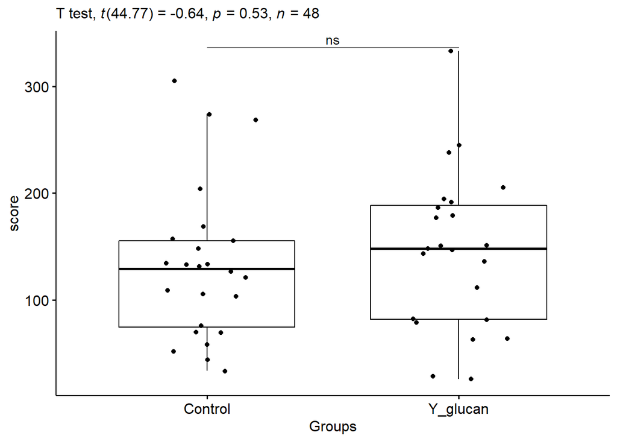

```r
# Create a box-plot
bxp <- ggboxplot(
  my_data, x = "group", y = "score",
  ylab = "score", xlab = "Groups", add = "jitter"
)

# Add p-value and significance levels
stat.test <- stat.test %>% add_xy_position(x = "group")
bxp +
  stat_pvalue_manual(stat.test, tip.length = 0) +
  labs(subtitle = get_test_label(stat.test, detailed = TRUE))
```

## 10.2. Flow cytometry - two-way ANOVA

```r
# Rotate input file from folder 'input_data_flow_cytometry' to perform the analysis for other immunological parameters:
my_data <- read.table("./input_data_flow_cytometry/Flow_cytometry_DC_MLN_CDC1_CD8086_BG.csv",
                      header = TRUE,
                      sep = ",",
                      stringsAsFactors = FALSE)

my_data$id <- as.factor(my_data$id)

my_data$group <- as.factor(my_data$group)

my_data$time <- as.factor(my_data$time)

# Inspect some random rows of the data by groups
set.seed(123)
my_data %>% sample_n_by(group, time, size = 1)
```

```
## # A tibble: 6 x 4
##   id    group    time  score
##   <fct> <fct>    <fct> <dbl>
## 1 7     Control  t1     69.4
## 2 7     Control  t2    305
## 3 3     Control  t3    157
## 4 6     Y_glucan t1     25.7
## 5 3     Y_glucan t2    179
## 6 2     Y_glucan t3    186
```

```r
#Extreme outliers are removed from the analysis.

my_data %>%
  group_by(time) %>%
  identify_outliers(score)
```

```
## # A tibble: 1 x 6
##   time  id    group   score is.outlier is.extreme
##   <fct> <fct> <fct>   <dbl> <lgl>      <lgl>
## 1 t3    1     Control   274 TRUE       FALSE
```

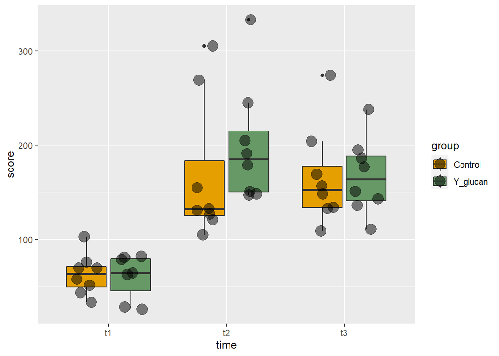

```r
#Jitter

my_data$group <- factor(my_data$group, levels = c("Control", "Y_glucan", "Control_med", "Y_glucan_med"))

my_data %>%
  filter(group %in% c("Control", "Y_glucan", "Control_med", "Y_glucan_med" )) %>%
  ggplot(aes(x=time, y=score, fill = factor(group))) +
  geom_boxplot() +
  labs(fill="group") +
  scale_fill_manual(values = c("#E69F00", "#669966", "#CCCCCC", "#999999")) +
  geom_point(position=position_jitterdodge(),alpha=0.5, size = 5)
```

```r
# Two-way ANOVA
# http://rstudio-pubs-static.s3.amazonaws.com/476761_eb23c47a75d6447688cb793ac8a3e461.html

res.aov2 <- aov(score ~ group + time, data = my_data)
summary(res.aov2)
```

```
##             Df Sum Sq Mean Sq F value   Pr(>F)
## group        1   2177    2177   0.872    0.356
## time         2 133227   66613  26.674 2.93e-08 ***
## Residuals   43 107385    2497
## ---
## Signif. codes:  0 '***' 0.001 '**' 0.01 '*' 0.05 '.' 0.1 ' ' 1
## 1 observation deleted due to missingness
```

```r
# Two-way ANOVA with interaction effect
# These two calls are equivalent
res.aov3 <- aov(score ~ group * time, data = my_data)
res.aov3 <- aov(score ~ group + time + group:time, data = my_data)
summary(res.aov3)
```

```
##             Df Sum Sq Mean Sq F value   Pr(>F)
## group        1   2177    2177   0.853    0.361
## time         2 133227   66613  26.109 4.87e-08 ***
## group:time   2   2779    1389   0.545    0.584
## Residuals   41 104606    2551
## ---
## Signif. codes:  0 '***' 0.001 '**' 0.01 '*' 0.05 '.' 0.1 ' ' 1
## 1 observation deleted due to missingness
```

```r
require("dplyr")
group_by(my_data, group, time) %>%
  summarise(
    count = n(),
    mean = mean(score, na.rm = TRUE),
    sd = sd(score, na.rm = TRUE)
  )
```

```
## # A tibble: 6 x 5
## # Groups:   group [2]
##   group    time  count  mean    sd
##   <fct>    <fct> <int> <dbl> <dbl>
## 1 Control  t1        8  63.0  21.6
## 2 Control  t2        8 168.   75.2
## 3 Control  t3        8 166    51.9
## 4 Y_glucan t1        8  60.4  24.1
## 5 Y_glucan t2        8 200.   63.4
## 6 Y_glucan t3        8 167.   40.0
```

```r
model.tables(res.aov2, type="means", se = TRUE)
```

```
## Design is unbalanced - use se.contrast() for se's
```

```
## Tables of means
## Grand mean
##
## 139.0702
##
##  group
##     Control Y_glucan
##       132.4      146
## rep    24.0       23
##
##  time
##        t1    t2    t3
##     62.06 183.9 166.4
## rep 15.00  16.0  16.0
```

```r
TukeyHSD(res.aov2, which = "time")
```

```
##   Tukey multiple comparisons of means
##     95% family-wise confidence level
##
## Fit: aov(formula = score ~ group + time, data = my_data)
##
## $time
##           diff       lwr       upr     p adj
## t2-t1 121.8554  78.25793 165.45284 0.0000001
## t3-t1 104.3554  60.75793 147.95284 0.0000020
## t3-t2 -17.5000 -60.38851  25.38851 0.5867905
```

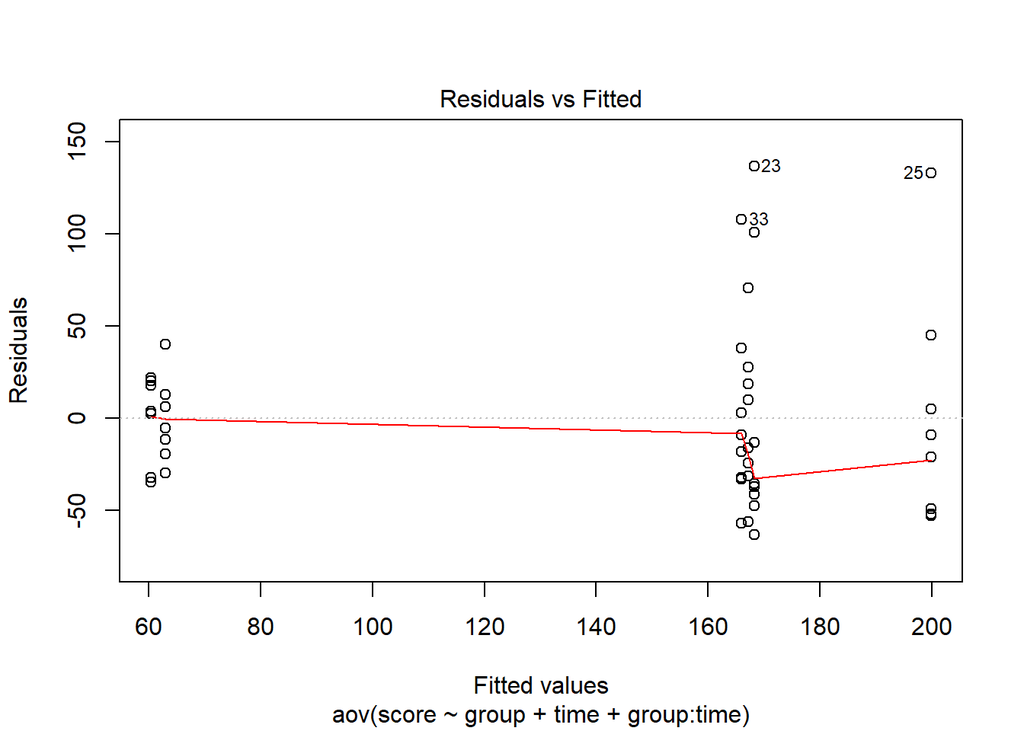

```r
# 1. Homogeneity of variances
plot(res.aov3, 1)
```

```r
library(car)
leveneTest(score ~ group*time, data = my_data)
```

```
## Levene's Test for Homogeneity of Variance (center = median)
##       Df F value Pr(>F)
## group  5  0.8258 0.5387
##       41
```

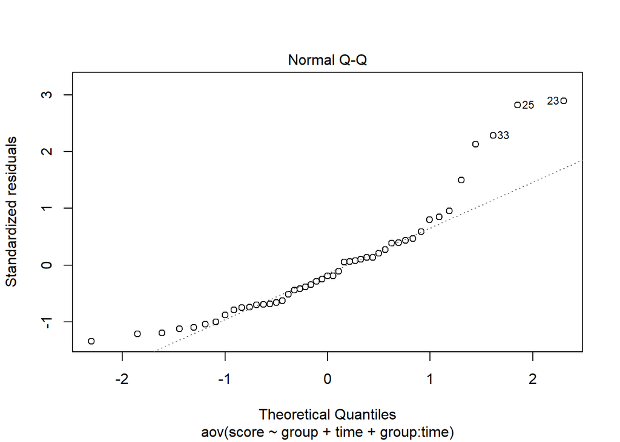

```r
# 2. Normality
plot(res.aov3, 2)
```

```r
# 3. Skewness

#Skewness between -2 and +2 acceptable (George and Malley, 2010).
library(moments)
skewness(my_data$score, na.rm = TRUE)
```

```
## [1] 0.641101
```

```r
# Extract the residuals
aov_residuals <- residuals(object = res.aov3)
# Run Shapiro-Wilk test
shapiro.test(x = aov_residuals)
```

```
##
##  Shapiro-Wilk normality test
##
## data:  aov_residuals
## W = 0.88361, p-value = 0.000225
```

## 10.3. Restimulation assay - t-test

```r
# Rotate input file from folder 'input_data_restimulation_assay' to perform the analysis for other immunological parameters:
my_data <- read.table("./input_data_restimulation_assay/Restimulation_Assay_MLN_IL10_CONA5.csv",
                      header = TRUE,
                      sep = ",",
                      stringsAsFactors = FALSE)

my_data$id <- as.factor(my_data$id)

my_data$group <- as.factor(my_data$group)

my_data$time <- as.factor(my_data$time)

# Load the data
data("genderweight", package = "datarium")

# Show a sample of the data by group
set.seed(123)
my_data %>% sample_n_by(group, size = 2)
```

```
## # A tibble: 4 x 4
##   id    group    time  score
##   <fct> <fct>    <fct> <dbl>
## 1 7     Control  t2    2852.
## 2 3     Control  t3     719.
## 3 6     Y_glucan t2    1293.
## 4 3     Y_glucan t1     692.
```

```r
my_data %>%
  group_by(group) %>%
  get_summary_stats(score, type = "mean_sd")
```

```
## # A tibble: 2 x 5
##   group    variable     n  mean    sd
##   <fct>    <chr>    <dbl> <dbl> <dbl>
## 1 Control  score       23 1099.  870.
## 2 Y_glucan score       23 1267.  881.
```

```r
# Save the data in two different vector
Y_glucan <- my_data %>%
  filter(group == "Y_glucan") %>%
  pull(score)
Control <- my_data %>%
  filter(group == "Control") %>%
  pull(score)

# Compute t-test
res <- t.test(Y_glucan, Control)
res
```

```
##
##  Welch Two Sample t-test
##
## data:  Y_glucan and Control
## t = 0.65064, df = 43.993, p-value = 0.5187
## alternative hypothesis: true difference in means is not equal to 0
## 95 percent confidence interval:
##  -352.4139  688.4389
## sample estimates:
## mean of x mean of y
##  1267.478  1099.465
```

```r
# Levene
levene_test(score ~ group, data = my_data)
```

```
## # A tibble: 1 x 4
##     df1   df2 statistic     p
##   <int> <int>     <dbl> <dbl>
## 1     1    44    0.0207 0.886
```

```r
# Compute t-test
res <- t.test(score ~ group, data = my_data)
res
```

```
##
##  Welch Two Sample t-test
##
## data:  score by group
## t = -0.65064, df = 43.993, p-value = 0.5187
## alternative hypothesis: true difference in means is not equal to 0
## 95 percent confidence interval:
##  -688.4389  352.4139
## sample estimates:
##  mean in group Control mean in group Y_glucan
##               1099.465               1267.478
```

```r
stat.test <- my_data %>%
  t_test(score ~ group) %>%
  add_significance()
stat.test
```

```
## # A tibble: 1 x 9
##   .y.   group1  group2      n1    n2 statistic    df     p p.signif
##   <chr> <chr>   <chr>    <int> <int>     <dbl> <dbl> <dbl> <chr>
## 1 score Control Y_glucan    24    24    -0.651  44.0 0.519 ns
```

```r
my_data %>%
  t_test(score ~ group, detailed = TRUE) %>%
  add_significance()
```

```
## # A tibble: 1 x 16
##   estimate estimate1 estimate2 .y.   group1 group2    n1    n2 statistic     p
##      <dbl>     <dbl>     <dbl> <chr> <chr>  <chr>  <int> <int>     <dbl> <dbl>
## 1    -168.     1099.     1267. score Contr~ Y_glu~    24    24    -0.651 0.519
## # ... with 6 more variables: df <dbl>, conf.low <dbl>, conf.high <dbl>,
## #   method <chr>, alternative <chr>, p.signif <chr>
```

```r
my_data %>% cohens_d(score ~ group, var.equal = FALSE)
```

```
## # A tibble: 1 x 7
##   .y.   group1  group2   effsize    n1    n2 magnitude
## * <chr> <chr>   <chr>      <dbl> <int> <int> <ord>
## 1 score Control Y_glucan  -0.192    24    24 negligible
```

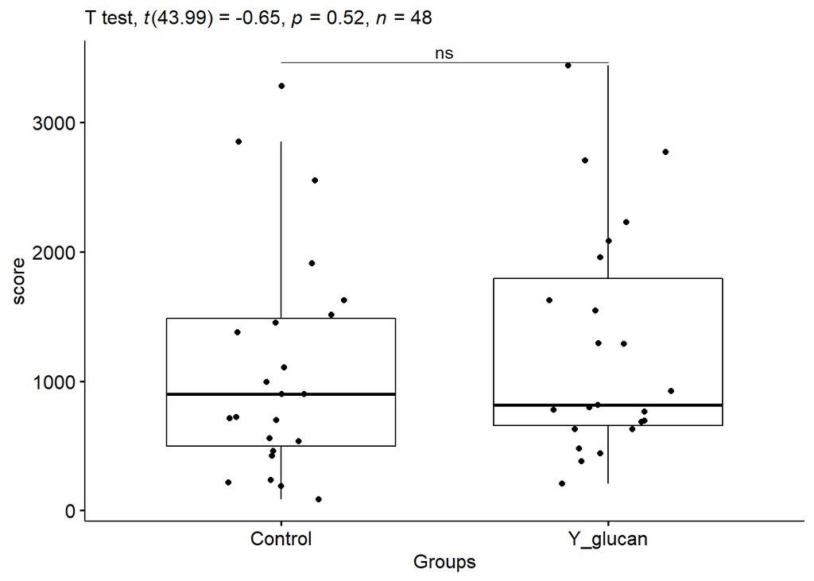

```r
# Create a box-plot
bxp <- ggboxplot(
  my_data, x = "group", y = "score",
  ylab = "score", xlab = "Groups", add = "jitter"
)

# Add p-value and significance levels
stat.test <- stat.test %>% add_xy_position(x = "group")
bxp +
  stat_pvalue_manual(stat.test, tip.length = 0) +
  labs(subtitle = get_test_label(stat.test, detailed = TRUE))
```

## 10.4. Rest. assay - two-way ANOVA

Restimulation assay - two-way ANOVA

```r
# Rotate input file from folder 'input_data_restimulation_assay' to perform the analysis for other immunological parameters:
my_data <- read.table("./input_data_restimulation_assay/Restimulation_Assay_MLN_IL10_CONA5.csv",
                      header = TRUE,
                      sep = ",",
                      stringsAsFactors = FALSE)

my_data$id <- as.factor(my_data$id)

my_data$group <- as.factor(my_data$group)

my_data$time <- as.factor(my_data$time)

# Inspect some random rows of the data by groups
set.seed(123)
my_data %>% sample_n_by(group, time, size = 1)
```

```
## # A tibble: 6 x 4
##   id    group    time  score
##   <fct> <fct>    <fct> <dbl>
## 1 7     Control  t1     991.
## 2 7     Control  t2    2852.
## 3 3     Control  t3     719.
## 4 6     Y_glucan t1    1289.
## 5 3     Y_glucan t2    1955.
## 6 2     Y_glucan t3     381.
```

```r
#Extreme outliers are removed from the analysis.

my_data %>%
  group_by(time) %>%
  identify_outliers(score)
```

```
## # A tibble: 2 x 6
##   time  id    group    score is.outlier is.extreme
##   <fct> <fct> <fct>    <dbl> <lgl>      <lgl>
## 1 t1    1     Y_glucan 2231. TRUE       FALSE
## 2 t3    1     Y_glucan 1545. TRUE       FALSE
```

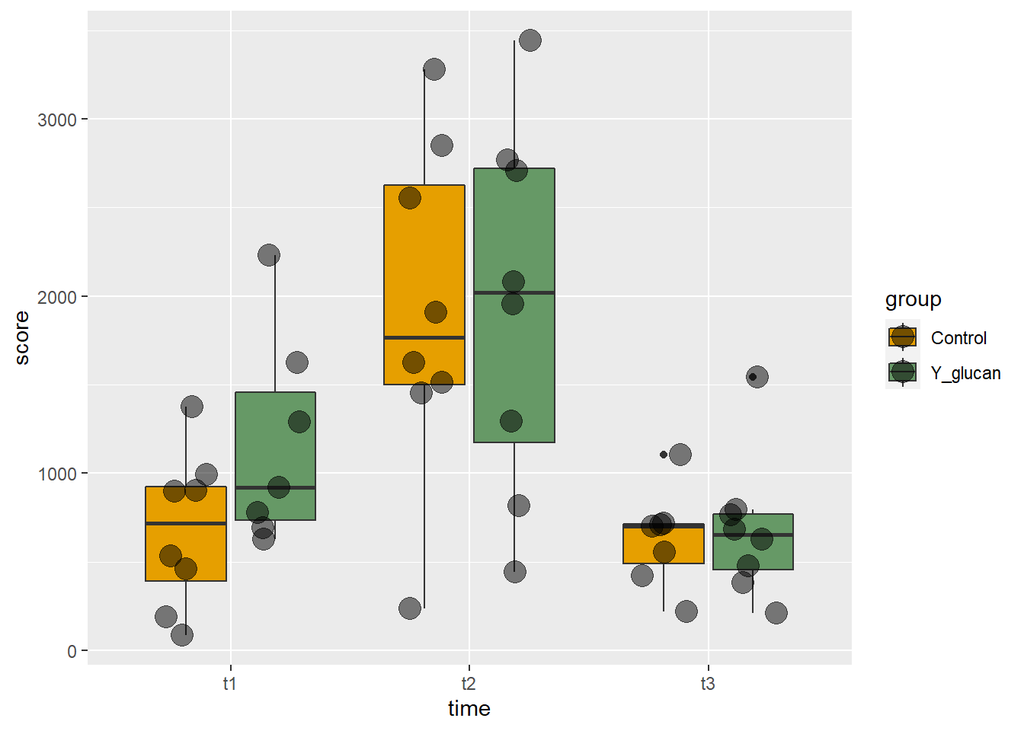

```r
#Jitter

my_data$group <- factor(my_data$group, levels = c("Control", "Y_glucan", "Control_med", "Y_glucan_med"))

my_data %>%
  filter(group %in% c("Control", "Y_glucan", "Control_med", "Y_glucan_med" )) %>%
  ggplot(aes(x=time, y=score, fill = factor(group))) +
  geom_boxplot() +
  labs(fill="group") +
  scale_fill_manual(values = c("#E69F00", "#669966", "#CCCCCC", "#999999")) +
  geom_point(position=position_jitterdodge(),alpha=0.5, size = 5)
```

```r
# Two-way ANOVA
# http://rstudio-pubs-static.s3.amazonaws.com/476761_eb23c47a75d6447688cb793ac8a3e461.html

res.aov2 <- aov(score ~ group + time, data = my_data)
summary(res.aov2)
```

```
##             Df   Sum Sq Mean Sq F value   Pr(>F)
## group        1   324624  324624   0.701    0.407
## time         2 14285532 7142766  15.420 9.52e-06 ***
## Residuals   42 19455387  463223
## ---
## Signif. codes:  0 '***' 0.001 '**' 0.01 '*' 0.05 '.' 0.1 ' ' 1
## 2 observations deleted due to missingness
```

```r
# Two-way ANOVA with interaction effect
# These two calls are equivalent
res.aov3 <- aov(score ~ group * time, data = my_data)
res.aov3 <- aov(score ~ group + time + group:time, data = my_data)
summary(res.aov3)
```

```
##             Df   Sum Sq Mean Sq F value   Pr(>F)
## group        1   324624  324624   0.686    0.412
## time         2 14285532 7142766  15.095 1.31e-05 ***
## group:time   2   527873  263936   0.558    0.577
## Residuals   40 18927514  473188
## ---
## Signif. codes:  0 '***' 0.001 '**' 0.01 '*' 0.05 '.' 0.1 ' ' 1
## 2 observations deleted due to missingness
```

```r
require("dplyr")
group_by(my_data, group, time) %>%
  summarise(
    count = n(),
    mean = mean(score, na.rm = TRUE),
    sd = sd(score, na.rm = TRUE)
  )
```

```
## # A tibble: 6 x 5
## # Groups:   group [2]
##   group    time  count  mean    sd
##   <fct>    <fct> <int> <dbl> <dbl>
## 1 Control  t1        8  679.  438.
## 2 Control  t2        8 1928.  958.
## 3 Control  t3        8  633.  279.
## 4 Y_glucan t1        8 1166.  590.
## 5 Y_glucan t2        8 1939. 1034.
## 6 Y_glucan t3        8  685.  401.
```

```r
model.tables(res.aov2, type="means", se = TRUE)
```

```
## Design is unbalanced - use se.contrast() for se's
```

```
## Tables of means
## Grand mean
##
## 1183.471
##
##  group
##     Control Y_glucan
##        1099     1267
## rep      23       23
##
##  time
##      t1   t2    t3
##     912 1933 655.2
## rep  15   16  15.0
```

```r
TukeyHSD(res.aov2, which = "time")
```

```
##   Tukey multiple comparisons of means
##     95% family-wise confidence level
##
## Fit: aov(formula = score ~ group + time, data = my_data)
##
## $time
##             diff        lwr       upr     p adj
## t2-t1  1021.1610   426.8876 1615.4345 0.0004243
## t3-t1  -256.8019  -860.5843  346.9805 0.5603017
## t3-t2 -1277.9629 -1872.2364 -683.6895 0.0000151
```

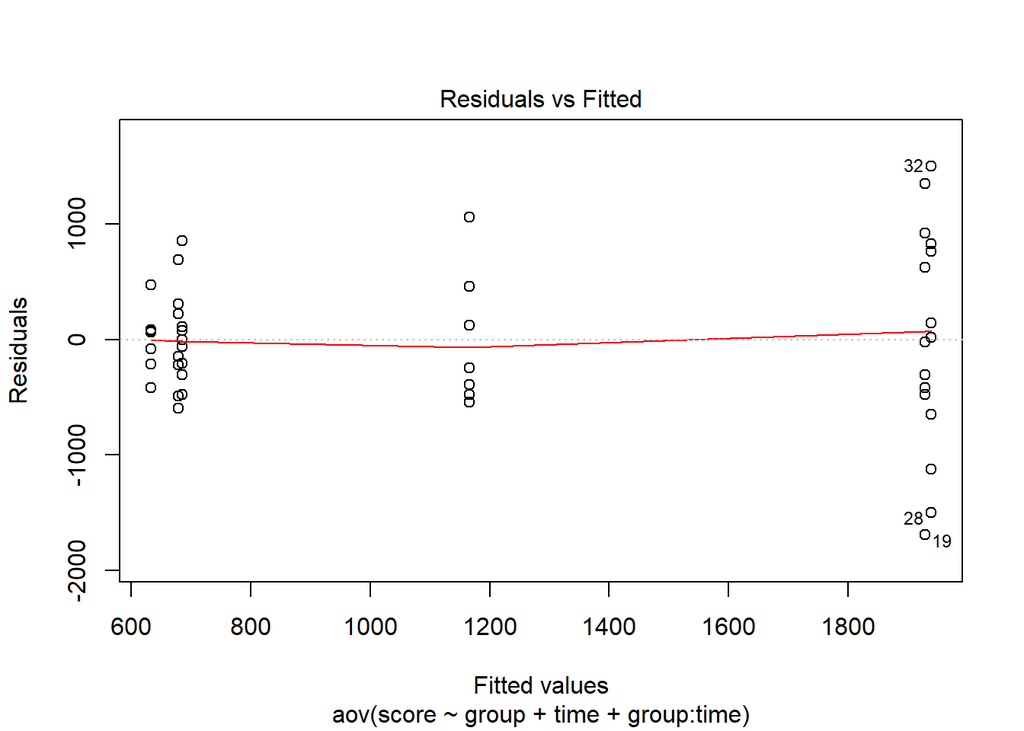

```r
# 1. Homogeneity of variances
plot(res.aov3, 1)
```

```r
library(car)
leveneTest(score ~ group*time, data = my_data)
```

```
## Levene's Test for Homogeneity of Variance (center = median)
##       Df F value  Pr(>F)
## group  5  2.7583 0.03119 *
##       40
## ---
## Signif. codes:  0 '***' 0.001 '**' 0.01 '*' 0.05 '.' 0.1 ' ' 1
```

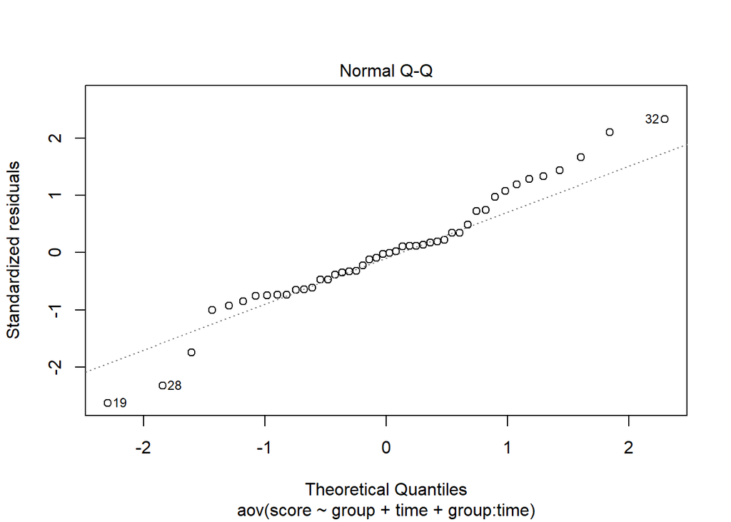

```r
# 2. Normality
plot(res.aov3, 2)
```

```r
# 3. Skewness

#Skewness between -2 and +2 acceptable (George and Malley, 2010).
library(moments)
skewness(my_data$score, na.rm = TRUE)
```

```
## [1] 1.011202
```

```r
# Extract the residuals
aov_residuals <- residuals(object = res.aov3)
# Run Shapiro-Wilk test
shapiro.test(x = aov_residuals)
```

```
##
##  Shapiro-Wilk normality test
##
## data:  aov_residuals
## W = 0.96949, p-value = 0.2653
```

## 10.5. Vaccination response t-test

```r
# Rotate input file from folder 'input_data_vaccination_response' to perform the analysis for other immunological parameters:
my_data <- read.table("./input_data_vaccination_response/Vaccination_Salmonella_IgA_BG.csv",
                      header = TRUE,
                      sep = ",",
                      stringsAsFactors = FALSE)

my_data$id <- as.factor(my_data$id)

my_data$group <- as.factor(my_data$group)

my_data$time <- as.factor(my_data$time)

# Load the data
data("genderweight", package = "datarium")

# Show a sample of the data by group
set.seed(123)
my_data %>% sample_n_by(group, size = 2)
```

```
## # A tibble: 4 x 4
##   id    group    time   score
##   <fct> <fct>    <fct>  <dbl>
## 1 15    Control  t2    0.226
## 2 15    Control  t1    0.0893
## 3 14    Y_Glucan t1    0.0675
## 4 3     Y_Glucan t1    0.144
```

```r
my_data %>%
  group_by(group) %>%
  get_summary_stats(score, type = "mean_sd")
```

```
## # A tibble: 2 x 5
##   group    variable     n  mean    sd
##   <fct>    <chr>    <dbl> <dbl> <dbl>
## 1 Control  score       47 0.391 0.344
## 2 Y_Glucan score       45 0.342 0.249
```

```r
# Save the data in two different vector
Y_glucan <- my_data %>%
  filter(group == "Y_Glucan") %>%
  pull(score)
Control <- my_data %>%
  filter(group == "Control") %>%
  pull(score)

# Compute t-test
res <- t.test(Y_glucan, Control)
res
```

```
##
##  Welch Two Sample t-test
##
## data:  Y_glucan and Control
## t = -0.78629, df = 83.872, p-value = 0.4339
## alternative hypothesis: true difference in means is not equal to 0
## 95 percent confidence interval:
##  -0.17303530  0.07497459
## sample estimates:
## mean of x mean of y
## 0.3420867 0.3911170
```

```r
# Levene
levene_test(score ~ group, data = my_data)
```

```
## # A tibble: 1 x 4
##     df1   df2 statistic     p
##   <int> <int>     <dbl> <dbl>
## 1     1    90      2.61 0.110
```

```r
# Compute t-test
res <- t.test(score ~ group, data = my_data)
res
```

```
##
##  Welch Two Sample t-test
##
## data:  score by group
## t = 0.78629, df = 83.872, p-value = 0.4339
## alternative hypothesis: true difference in means is not equal to 0
## 95 percent confidence interval:
##  -0.07497459  0.17303530
## sample estimates:
##  mean in group Control mean in group Y_Glucan
##              0.3911170              0.3420867
```

```r
stat.test <- my_data %>%
  t_test(score ~ group) %>%
  add_significance()
stat.test
```

```
## # A tibble: 1 x 9
##   .y.   group1  group2      n1    n2 statistic    df     p p.signif
##   <chr> <chr>   <chr>    <int> <int>     <dbl> <dbl> <dbl> <chr>
## 1 score Control Y_Glucan    48    48     0.786  83.9 0.434 ns
```

```r
my_data %>%
  t_test(score ~ group, detailed = TRUE) %>%
  add_significance()
```

```
## # A tibble: 1 x 16
##   estimate estimate1 estimate2 .y.   group1 group2    n1    n2 statistic     p
##      <dbl>     <dbl>     <dbl> <chr> <chr>  <chr>  <int> <int>     <dbl> <dbl>
## 1   0.0490     0.391     0.342 score Contr~ Y_Glu~    48    48     0.786 0.434
## # ... with 6 more variables: df <dbl>, conf.low <dbl>, conf.high <dbl>,
## #   method <chr>, alternative <chr>, p.signif <chr>
```

```r
my_data %>% cohens_d(score ~ group, var.equal = FALSE)
```

```
## # A tibble: 1 x 7
##   .y.   group1  group2   effsize    n1    n2 magnitude
## * <chr> <chr>   <chr>      <dbl> <int> <int> <ord>
## 1 score Control Y_Glucan   0.163    48    48 negligible
```

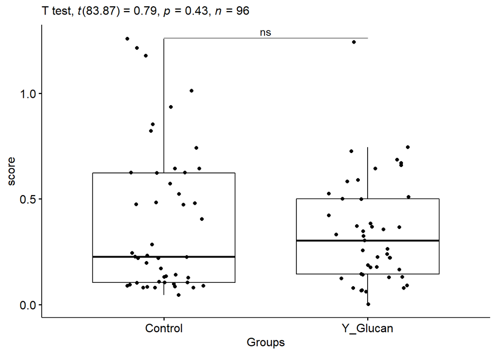

```r
# Create a box-plot
bxp <- ggboxplot(
  my_data, x = "group", y = "score",
  ylab = "score", xlab = "Groups", add = "jitter"
)

# Add p-value and significance levels
stat.test <- stat.test %>% add_xy_position(x = "group")
bxp +
  stat_pvalue_manual(stat.test, tip.length = 0) +
  labs(subtitle = get_test_label(stat.test, detailed = TRUE))
```

## 10.6. Vaccination resp. - ANOVA

Vaccination response - two-way ANOVA

```r
# Rotate input file from folder 'input_data_vaccination_response' to perform the analysis for other immunological parameters:
my_data <- read.table("./input_data_vaccination_response/Vaccination_Salmonella_IgA_BG.csv",
                      header = TRUE,
                      sep = ",",
                      stringsAsFactors = FALSE)

my_data$id <- as.factor(my_data$id)

my_data$group <- as.factor(my_data$group)

my_data$time <- as.factor(my_data$time)

# Inspect some random rows of the data by groups
set.seed(123)
my_data %>% sample_n_by(group, time, size = 1)
```

```
## # A tibble: 6 x 4
##   id    group    time   score
##   <fct> <fct>    <fct>  <dbl>
## 1 15    Control  t1    0.0893
## 2 15    Control  t2    0.226
## 3 3     Control  t3    1.01
## 4 14    Y_Glucan t1    0.0675
## 5 3     Y_Glucan t2    0.222
## 6 10    Y_Glucan t3    0.509
```

```r
#Extreme outliers are removed from the analysis.

my_data %>%
  group_by(time) %>%
  identify_outliers(score)
```

```
## # A tibble: 4 x 6
##   time  id    group    score is.outlier is.extreme
##   <fct> <fct> <fct>    <dbl> <lgl>      <lgl>
## 1 t1    4     Y_Glucan 0.238 TRUE       FALSE
## 2 t1    5     Y_Glucan 0.304 TRUE       FALSE
## 3 t1    11    Y_Glucan 0.256 TRUE       FALSE
## 4 t2    16    Control  1.18  TRUE       FALSE
```

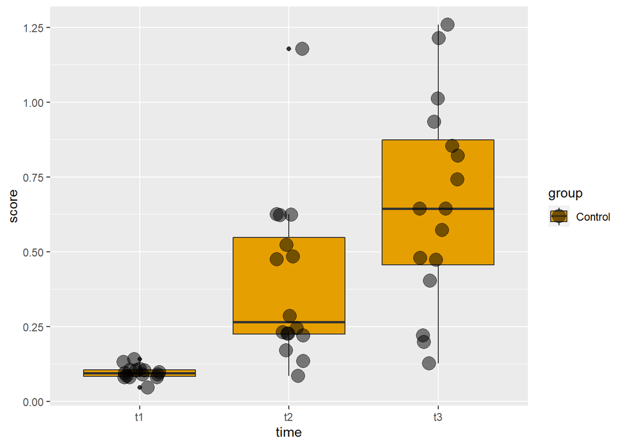

```r
#Jitter

my_data$group <- factor(my_data$group, levels = c("Control", "Y_Glucan", "Control_med", "Y_glucan_med"))

my_data %>%
  filter(group %in% c("Control", "Y_glucan", "Control_med", "Y_glucan_med" )) %>%
  ggplot(aes(x=time, y=score, fill = factor(group))) +
  geom_boxplot() +
  labs(fill="group") +
  scale_fill_manual(values = c("#E69F00", "#669966", "#CCCCCC", "#999999")) +
  geom_point(position=position_jitterdodge(),alpha=0.5, size = 5)
```

```r
# Two-way ANOVA
# http://rstudio-pubs-static.s3.amazonaws.com/476761_eb23c47a75d6447688cb793ac8a3e461.html

res.aov2 <- aov(score ~ group + time, data = my_data)
summary(res.aov2)
```

```
##             Df Sum Sq Mean Sq F value   Pr(>F)
## group        1  0.055  0.0553   1.032    0.312
## time         2  3.444  1.7219  32.156 3.29e-11 ***
## Residuals   88  4.712  0.0535
## ---
## Signif. codes:  0 '***' 0.001 '**' 0.01 '*' 0.05 '.' 0.1 ' ' 1
## 4 observations deleted due to missingness
```

```r
# Two-way ANOVA with interaction effect
# These two calls are equivalent
res.aov3 <- aov(score ~ group * time, data = my_data)
res.aov3 <- aov(score ~ group + time + group:time, data = my_data)
summary(res.aov3)
```

```
##             Df Sum Sq Mean Sq F value   Pr(>F)
## group        1  0.055  0.0553   1.039    0.311
## time         2  3.444  1.7219  32.384 3.28e-11 ***
## group:time   2  0.140  0.0698   1.313    0.274
## Residuals   86  4.573  0.0532
## ---
## Signif. codes:  0 '***' 0.001 '**' 0.01 '*' 0.05 '.' 0.1 ' ' 1
## 4 observations deleted due to missingness
```

```r
require("dplyr")
group_by(my_data, group, time) %>%
  summarise(
    count = n(),
    mean = mean(score, na.rm = TRUE),
    sd = sd(score, na.rm = TRUE)
  )
```

```
## # A tibble: 6 x 5
## # Groups:   group [2]
##   group    time  count   mean     sd
##   <fct>    <fct> <int>  <dbl>  <dbl>
## 1 Control  t1       16 0.0955 0.0225
## 2 Control  t2       16 0.397  0.279
## 3 Control  t3       16 0.662  0.343
## 4 Y_Glucan t1       16 0.138  0.0816
## 5 Y_Glucan t2       16 0.372  0.189
## 6 Y_Glucan t3       16 0.516  0.272
```

```r
model.tables(res.aov2, type="means", se = TRUE)
```

```
## Design is unbalanced - use se.contrast() for se's
```

```
## Tables of means
## Grand mean
##
## 0.3671348
##
##  group
##     Control Y_Glucan
##      0.3911   0.3421
## rep 47.0000  45.0000
##
##  time
##          t1      t2      t3
##      0.1173  0.3845  0.5915
## rep 30.0000 31.0000 31.0000
```

```r
TukeyHSD(res.aov2, which = "time")
```

```
##   Tukey multiple comparisons of means
##     95% family-wise confidence level
##
## Fit: aov(formula = score ~ group + time, data = my_data)
##
## $time
##            diff        lwr       upr     p adj
## t2-t1 0.2672593 0.12597045 0.4085482 0.0000589
## t3-t1 0.4742513 0.33296238 0.6155402 0.0000000
## t3-t2 0.2069919 0.06686593 0.3471179 0.0019546
```

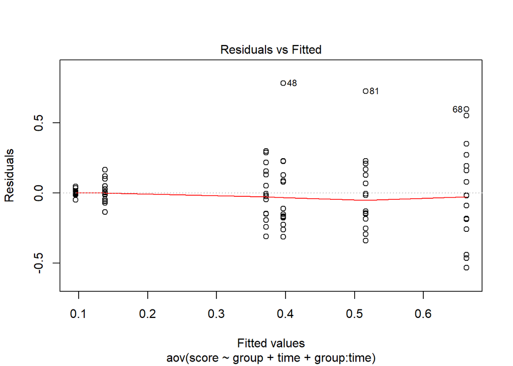

```r
# 1. Homogeneity of variances
plot(res.aov3, 1)
```

```r
library(car)
leveneTest(score ~ group*time, data = my_data)
```

```
## Levene's Test for Homogeneity of Variance (center = median)
##       Df F value    Pr(>F)
## group  5  6.1382 6.558e-05 ***
##       86
## ---
## Signif. codes:  0 '***' 0.001 '**' 0.01 '*' 0.05 '.' 0.1 ' ' 1
```

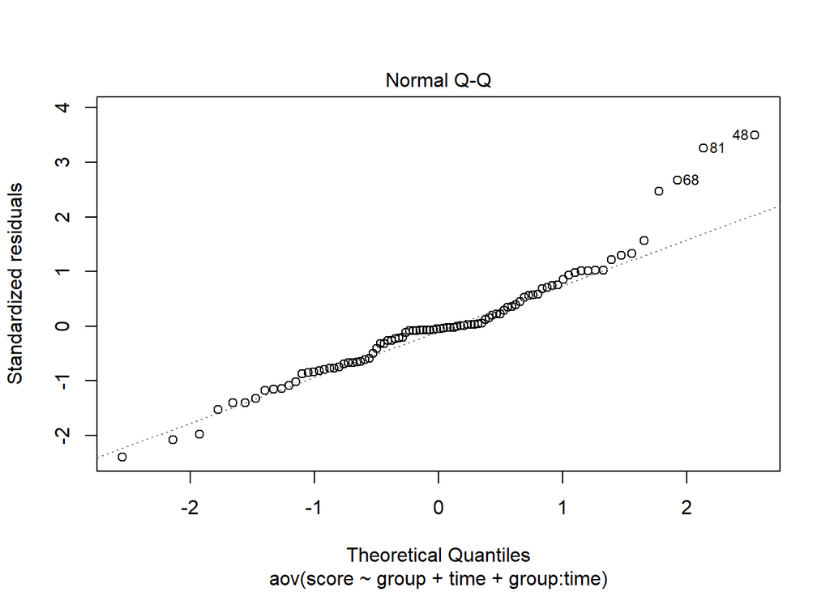

```r
# 2. Normality
plot(res.aov3, 2)
```

```r
# 3. Skewness

#Skewness between -2 and +2 acceptable (George and Malley, 2010).
library(moments)
skewness(my_data$score, na.rm = TRUE)
```

```
## [1] 1.179768
```

```r
# Extract the residuals
aov_residuals <- residuals(object = res.aov3)
# Run Shapiro-Wilk test
shapiro.test(x = aov_residuals)
```

```
##
##  Shapiro-Wilk normality test
##
## data:  aov_residuals
## W = 0.94218, p-value = 0.0004861
```

# 11. Correlation plot

## 11.1. Prepare data

```r
ile <- readRDS("./phyobjects/ps1.decontam.rds")
ile <- subset_samples(ile, Day_of_study_factor == "Day_27")
ile <- subset_samples(ile, Origin == "ileum_digesta")
ile <- microbiome::aggregate_taxa(ile, "Genus")
ile.r <- microbiome::transform(ile, "compositional")
#Prevalence filter:
ile.r <- filter_taxa(ile.r, function(x) sum(x > 0.001) > (0.50*length(x)), TRUE)
```

## 11.2. Extract data from phyloseq object

```r
OTU1 = as(otu_table(ile.r), "matrix")
# transpose if necessary
if(taxa_are_rows(ile.r)){OTU1 <- t(OTU1)}
# Coerce to data.frame
OTUdf = as.data.frame(OTU1)
write.csv(OTUdf, file = "./output_data/OTUdf_all_treatments_day27_ileum_genera_filter_sum0.001_prev0.5.csv") #this file was used to manually combine genera abundances with day 27 ileum sample data
```

## 11.3. Import ileum data file

```r
my_data <- read.table("./input_data/ileum_metadata_plus_genera_abundances_for_correlation_figure.csv",
                      header = TRUE,
                      sep = ",",
                      stringsAsFactors = FALSE)
my_data <- my_data
head(my_data, 6)
```

```
##   Weight_birth Weight_day_14 Weight_at_day_26 pH_jejunum pH_ileum pH_caecum
## 1         1.28          4.38              7.9       6.06     7.11      6.18
## 2         1.68          5.90             10.0       7.10     8.40      6.32
## 3         2.13          4.67              7.8       7.05     8.03      6.08
## 4         1.85          5.73               NA       6.84     8.14      6.43
## 5         1.23          4.25              7.8         NA       NA      6.10
## 6         2.07          6.12              9.6       7.66     8.71      6.52
##   pH_colon CTL_perc_MLN_d27 CTL_ki67_MLN_d27 MemoryT_perc_MLN_d27
## 1     6.51             21.3             26.4                 5.81
## 2     6.95             19.5             21.4                 7.30
## 3     7.31             15.7             20.2                 5.77
## 4     5.94             17.9             28.1                 2.40
## 5     6.86             17.9             29.2                 4.32
## 6     5.79             24.6             29.3                 2.91
##   MemoryT_perc_CD4highCD8low_MLN_d27 MemoryT_Ki67_CD4highCD8low_MLN_d27
```

[output cut: 76 more lines]

```r
# Summary of data
summary(my_data)
```

```
##   Weight_birth   Weight_day_14   Weight_at_day_26   pH_jejunum
##  Min.   :1.040   Min.   :2.790   Min.   : 5.030   Min.   :6.060
##  1st Qu.:1.235   1st Qu.:4.290   1st Qu.: 7.800   1st Qu.:6.997
##  Median :1.650   Median :5.000   Median : 8.575   Median :7.315
##  Mean   :1.548   Mean   :4.839   Mean   : 8.381   Mean   :7.131
##  3rd Qu.:1.725   3rd Qu.:5.510   3rd Qu.: 9.400   3rd Qu.:7.407
##  Max.   :2.130   Max.   :6.120   Max.   :10.000   Max.   :7.660
##                                  NA's   :1        NA's   :3
##     pH_ileum       pH_caecum        pH_colon     CTL_perc_MLN_d27
##  Min.   :7.070   Min.   :6.080   Min.   :5.790   Min.   :13.40
##  1st Qu.:7.300   1st Qu.:6.175   1st Qu.:6.470   1st Qu.:17.90
##  Median :7.640   Median :6.390   Median :6.730   Median :19.60
##  Mean   :7.763   Mean   :6.402   Mean   :6.694   Mean   :20.04
##  3rd Qu.:8.140   3rd Qu.:6.555   3rd Qu.:6.915   3rd Qu.:22.85
##  Max.   :8.710   Max.   :7.010   Max.   :7.730   Max.   :26.40
##  NA's   :2                                       NA's   :1
##  CTL_ki67_MLN_d27 MemoryT_perc_MLN_d27 MemoryT_perc_CD4highCD8low_MLN_d27
##  Min.   :16.10    Min.   :1.070        Min.   :26.20
##  1st Qu.:24.02    1st Qu.:2.265        1st Qu.:52.40
##  Median :27.25    Median :2.910        Median :57.00
##  Mean   :27.68    Mean   :3.482        Mean   :60.04
##  3rd Qu.:29.27    3rd Qu.:4.553        3rd Qu.:73.55
##  Max.   :45.20    Max.   :7.300        Max.   :90.50
##  NA's   :1        NA's   :1            NA's   :1
##  MemoryT_Ki67_CD4highCD8low_MLN_d27 MemoryT_perc_CD4lowCD8high_MLN_d27
##  Min.   :28.80                      Min.   : 9.52
##  1st Qu.:37.00                      1st Qu.:23.98
##  Median :40.85                      Median :39.40
##  Mean   :44.58                      Mean   :37.49
##  3rd Qu.:48.88                      3rd Qu.:43.45
##  Max.   :69.80                      Max.   :71.30
##  NA's   :1                          NA's   :1
##  MemoryT_Ki67_CD4lowCD8high_MLN_d27 HelperT_perc_MLN_d27 HelperT_Ki67_MLN_d27
##  Min.   :23.80                      Min.   :60.90        Min.   :13.60
##  1st Qu.:30.27                      1st Qu.:65.50        1st Qu.:15.28
##  Median :42.85                      Median :68.20        Median :18.80
##  Mean   :40.00                      Mean   :68.32        Mean   :20.79
##  3rd Qu.:49.20                      3rd Qu.:71.65        3rd Qu.:23.23
##  Max.   :55.80                      Max.   :73.90        Max.   :33.20
##  NA's   :1                          NA's   :1            NA's   :1
```

[output cut: 49 more lines]

```
##  Min.   :0.00000             Min.   :0.005936   Min.   :0.007063
##  1st Qu.:0.02921             1st Qu.:0.033550   1st Qu.:0.027560
##  Median :0.06719             Median :0.109685   Median :0.036324
##  Mean   :0.10622             Mean   :0.098730   Mean   :0.060560
##  3rd Qu.:0.18144             3rd Qu.:0.126407   3rd Qu.:0.083054
##  Max.   :0.28562             Max.   :0.226620   Max.   :0.183378
##
##   Turicibacter      Veillonella       Actinobacillus      Haemophilus
##  Min.   :0.00000   Min.   :0.000000   Min.   :0.000000   Min.   :0.000000
##  1st Qu.:0.01423   1st Qu.:0.000000   1st Qu.:0.000000   1st Qu.:0.005349
##  Median :0.05942   Median :0.001180   Median :0.001127   Median :0.007578
##  Mean   :0.06570   Mean   :0.006790   Mean   :0.002613   Mean   :0.013364
##  3rd Qu.:0.08061   3rd Qu.:0.006146   3rd Qu.:0.001989   3rd Qu.:0.012141
##  Max.   :0.25448   Max.   :0.052143   Max.   :0.015246   Max.   :0.057469
##
```

```r
# Turn into numeric value
my_data$cdc2_8086_MLN_d27<- as.numeric(my_data$cdc2_8086_MLN_d27)

str(my_data)
```

```
## 'data.frame':    15 obs. of  40 variables:
##  $ Weight_birth                      : num  1.28 1.68 2.13 1.85 1.23 2.07 1.68 1.04 1.23 1.24 ...
##  $ Weight_day_14                     : num  4.38 5.9 4.67 5.73 4.25 6.12 5.07 4 3.8 4.33 ...
##  $ Weight_at_day_26                  : num  7.9 10 7.8 NA 7.8 9.6 8.96 7.1 7.53 8.3 ...
##  $ pH_jejunum                        : num  6.06 7.1 7.05 6.84 NA 7.66 7.32 7.31 NA 7.39 ...
##  $ pH_ileum                          : num  7.11 8.4 8.03 8.14 NA 8.71 7.64 7.55 7.62 7.07 ...
##  $ pH_caecum                         : num  6.18 6.32 6.08 6.43 6.1 6.52 6.39 6.59 7.01 6.16 ...
##  $ pH_colon                          : num  6.51 6.95 7.31 5.94 6.86 5.79 6.73 6.73 6.75 6.51 ...
##  $ CTL_perc_MLN_d27                  : num  21.3 19.5 15.7 17.9 17.9 24.6 19.7 23.1 NA 16.2 ...
##  $ CTL_ki67_MLN_d27                  : num  26.4 21.4 20.2 28.1 29.2 29.3 16.1 28.5 NA 24.1 ...
##  $ MemoryT_perc_MLN_d27              : num  5.81 7.3 5.77 2.4 4.32 2.91 3.63 4.63 NA 1.07 ...
##  $ MemoryT_perc_CD4highCD8low_MLN_d27: num  43.1 73.4 54.5 76 52 55.2 46.7 75.4 NA 73.6 ...
##  $ MemoryT_Ki67_CD4highCD8low_MLN_d27: num  45.5 28.8 37 51.9 35.4 39.6 35 69.8 NA 41.1 ...
##  $ MemoryT_perc_CD4lowCD8high_MLN_d27: num  55.1 24.5 43.5 21.5 43.3 41.1 51 23 NA 23.8 ...
##  $ MemoryT_Ki67_CD4lowCD8high_MLN_d27: num  36.8 24.8 24 28.3 49.8 41.9 23.8 50.6 NA 46.8 ...
```

[output cut: 26 more lines]

## 11.4. Create correlation plot

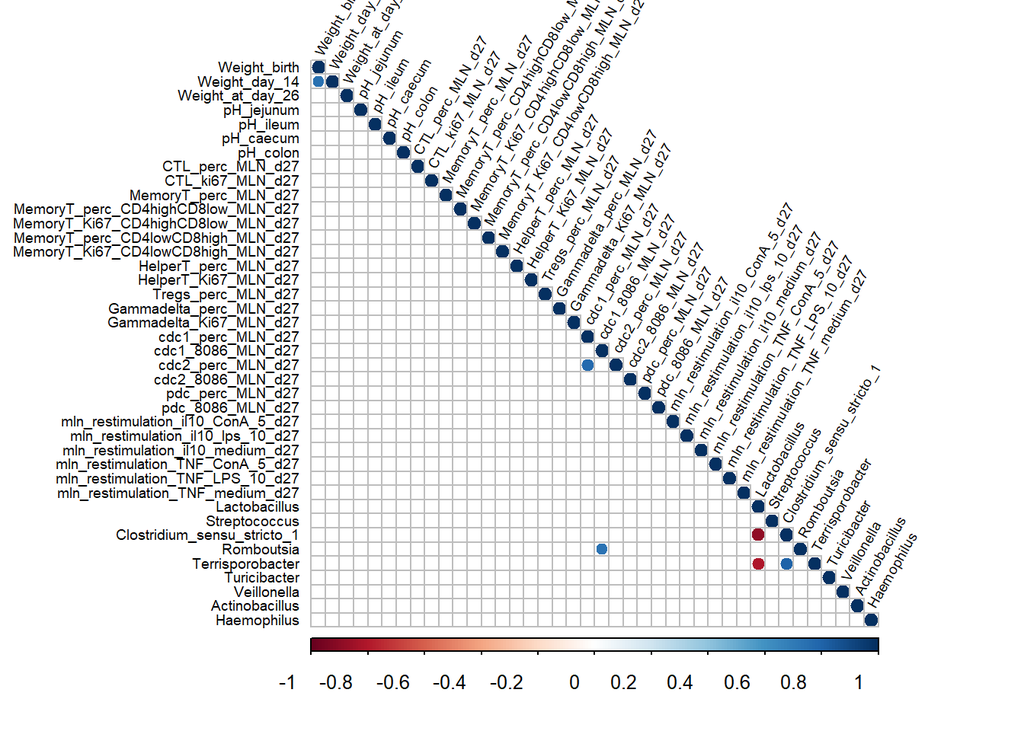

```r
# P.adjust: Calculated using Benjamini-Hockberg (BH) method
cors<-cor(my_data)
cor.mtest <- function(mat, conf.level = 0.95) {
  mat <- as.matrix(mat)
  n <- ncol(mat)
  p.mat <- lowCI.mat <- uppCI.mat <- matrix(NA, n, n)
  diag(p.mat) <- 0
  diag(lowCI.mat) <- diag(uppCI.mat) <- 1
  for (i in 1:(n - 1)) {
    for (j in (i + 1):n) {
      tmp <- cor.test(mat[, i], mat[, j], conf.level = conf.level)
      p.mat[i, j] <- p.mat[j, i] <- tmp$p.value
      lowCI.mat[i, j] <- lowCI.mat[j, i] <- tmp$conf.int[1]
      uppCI.mat[i, j] <- uppCI.mat[j, i] <- tmp$conf.int[2]
    }
  }
  return(list(p.mat, lowCI.mat, uppCI.mat))
}
res1 <- cor.mtest(my_data, 0.95)

#You can vectorize your p-value matrix (e.g. res1), which has been returned by cor.mtest function. Afterwards, p.adjust function is  used to get the adjusted p-values.
pAdj <- p.adjust(c(res1[[1]]), method = "BH")
#Then create the original matrix with adjusted p-values.
resAdj <- matrix(pAdj, ncol = dim(res1[[1]])[1])
#Then the corrplot function is used to create the plot containing adjusted p-values.
corrplot(cors, p.mat = resAdj, tl.col = "black", sig.level=0.05, insig="blank", cl.align="r", tl.cex=0.6, order="original", na.label="square", na.label.col = "white", type="lower", tl.srt=60, cl.ratio=0.1)
```

```r
# Save as pdf
pdf("./figures/Correlation_plot.pdf", width=10, height=10)
corrplot(cors, p.mat = resAdj, sig.level=0.05, insig="blank", cl.align="r", tl.cex=0.6, order="original", na.label="square", na.label.col = "white", tl.col = "black", type="lower", tl.srt=60, cl.ratio=0.1)
dev.off() #The final figure can be found as Supplementary Figure S9 of the manuscript
```

# 12. pH Boxplot

Figure was generated using code below, and was then manually exported. This is why it is not showing up in the ‘figures’ folder. The unprocessed figure can be found under its individual folder.

## 12.1. Import and prepare data

```r
my_data <- read.table("./input_data/pH_of_GI_segments.csv",
                      header = TRUE,
                      sep = ",",
                      stringsAsFactors = FALSE)

# Convert 'id', 'group', 'time' and 'treatment' to factors:

my_data$id <- as.factor(my_data$id)
my_data$group <- factor(my_data$group, levels = c("jejunum", "ileum", "caecum", "colon"))
my_data$time <- as.factor(my_data$time)
my_data$treatment <- as.factor(my_data$treatment)
```

## 12.2. Create boxplot

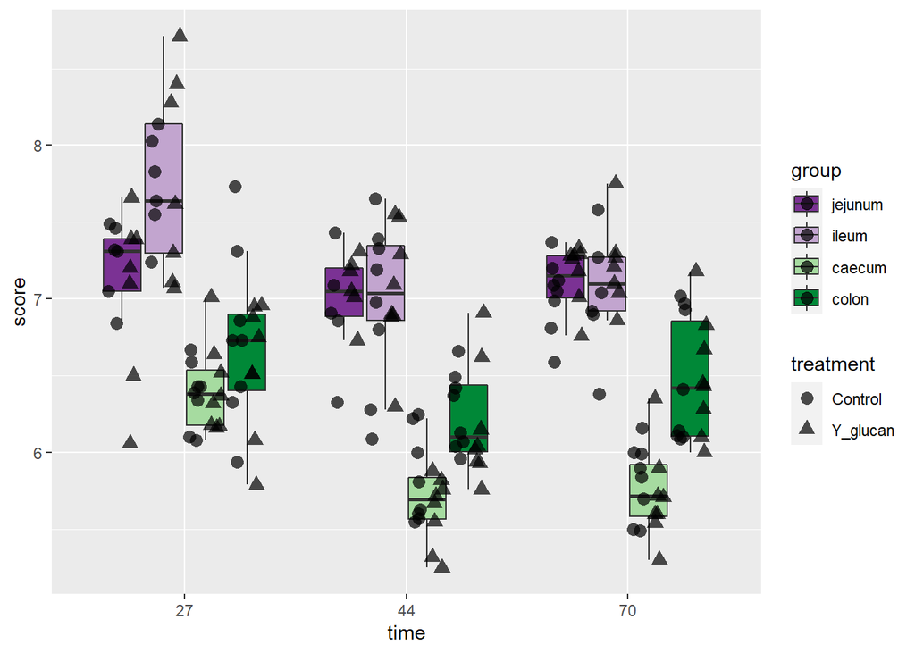

```r
p <- ggplot(my_data, aes(x=time, y=score, fill = factor(group))) +
  geom_boxplot(outlier.shape = NA) + scale_fill_brewer(palette="PRGn") +   labs(fill="group")
p <- p + geom_point(position=position_jitterdodge(jitter.width = 0.2), aes(fill = factor(group), shape=treatment), alpha=0.7, size = 3)
p
```

# 13. R version and Packages used

```r
version
```

```
##                _
## platform       x86_64-w64-mingw32
## arch           x86_64
## os             mingw32
## system         x86_64, mingw32
## status
## major          3
## minor          6.1
## year           2019
## month          07
## day            05
## svn rev        76782
## language       R
## version.string R version 3.6.1 (2019-07-05)
## nickname       Action of the Toes
```